# Análisis estadístico Albahaca

Camilo Vega Ramírez

19 de abril de 2019

# 0 Introducción.

Mediante el presente documento, tomaremos los datos albahaca recolectados en cama contenida y en sistema acuapónico por el grupo de acuaponía de la Universidad militar, y realizaremos un análisis estadístico sobre los mismos para así determinar si existen diferencias significativas entre los dos sistemas para los datos de las variables recolectadas, así mismo de existir estas diferencias calcularemos los intervalos de confianza para las mismas.

## 0.1 Preparación de datos, carga de paquetes y funciones locales.

El presente documento está escrito en Markdown usando para el análisis estadístico el programa R. Los bloques de código cada una de las secciones se encontrarán ocultos, pero se podrá acceder a todos ellos dando clic en el botón “Code” ubicado en la parte superior derecha de este documento y luego dando clic en la opción “Show All Code”, o alternativamente se podrá acceder a cada bloque por separado dando clic en los distintos botones “Code” que aparecerán a la derecha en las diferentes secciones del documento.

Los datos usados en el presente análisis se encuentran en la hoja de cálculo “datosAlbahaca.xlsx” que se anexa dentro de la carpeta de este documento.

En el código de R suministrado a continuación se cargarán los paquetes, hojas de Excel y funciones locales a usar.

```r
#Paquetes a usar
library(readxl)
library(tidyverse)
library(lme4)
library(lmerTest)
library(MASS)
library(car)
library(bestNormalize)
library(ggcorrplot)
library(gridExtra)
library(grid)
library(parallel)
library(optimx)

#Función local para calcular la dispersión de modelos poisson y binomiales negativos
dispersion <- function(model, modeltype = "p")
{
  A <- sum(resid(model, type = "pearson") ^ 2)
  if(modeltype %in% c("poisson", "quasipoisson"))
  {
    B <- length(resid(model)) - length(coef(model))
  }
  if(modeltype %in% c("nb", "negativebinomial"))
  {
    B <- length(resid(model)) - (length(coef(model)) + 1)
  }
  DISP <- A / B
  return(DISP)
}

#Función local para calcular los intervalos de confianza sobre datos simulados
bootCI <- function(merBoot) {
  return(
    data.frame(lwr = apply(merBoot$t, 2, function(x) as.numeric(quantile(x, probs=.025, na.rm=TRUE))),
               fit = apply(merBoot$t, 2, function(x) as.numeric(quantile(x, probs=.5, na.rm=TRUE))),
               upr = apply(merBoot$t, 2, function(x) as.numeric(quantile(x, probs=.975, na.rm=TRUE)))
    )
  )
}


#Cargando hoja albahaca
albahaca <- read_excel("datosAlbahaca.xlsx", sheet = "albahaca") %>%
  mutate_at(.vars = vars(sistema,id_bloque,variedad), .funs = funs(as.factor(.))) %>%
  mutate_at(.vars = vars(DDS,tallos_totales), .funs = funs(as.integer(.)))

#Cargando hoja cosechalba
cosechalba <- read_excel("datosAlbahaca.xlsx", sheet = "cosechalba") %>%
  mutate_at(.vars = vars(sistema,id_bloque,variedad), .funs = funs(as.factor(.)))

#Cargando hoja SPADalba
SPADalba <- read_excel("datosAlbahaca.xlsx", sheet = "SPADalba") %>%
  mutate_at(.vars = vars(sistema,id_bloque,variedad), .funs = funs(as.factor(.)))

#Cargando hoja secofrescoalba
secofrescoalba <- read_excel("datosAlbahaca.xlsx", sheet = "secofrescoalba") %>%
  mutate_at(.vars = vars(sistema,id_bloque,variedad), .funs = funs(as.factor(.)))
```

## 0.1 Estructura de los análisis.

El objetivo del presente análisis es el de establecer si existen diferencias estadísticamente significativas en las diversas variables medidas para sus promedios en Sistema Acuapónico y en Cama Contenida, por lo tanto, nuestra hipótesis nula, para las distintas variables, será que la media del sistema acuapónico es igual a la media del sistema cama contenida ($H_0: {\mu}_{Acuaponico} = {\mu}_{Cama Contenida}$) y nuestra hipótesis alternativa que estas medias son distintas ($H_1: {\mu}_{Acuaponico} \not= {\mu}_{Cama Contenida}$). Luego para aquellas variables significativas calcularemos sus respectivos intervalos de confianza con un nivel del 95%. Para llevar acabo lo anterior usaremos los siguientes pasos:

- Primero calcularemos el tamaño de muestra mínimo necesario (con un $\alpha = 0.05$ y con un $Poder(1-\beta) = 0.8$) para que la diferencia entre las medias de la variable analizar pueda ser usada para hacer inferencia, luego se compararemos con los tamaños de muestra de los datos obtenidos. Dado el caso que el tamaño de muestra real sea menor al necesario para inferir, concluiremos que no se tienen suficientes datos necesarios para rechazar la hipótesis nula.
- Si el tamaño de la muestra real es igual o superior al necesario para inferir, continuaremos el proceso haciendo un Análisis Exploratorio de Datos, donde miraremos la distribución de la variable a analizar tanto de forma individual, (para darnos una idea de si es necesario aplicar transformaciones a los datos), así como su interacción con los sistemas (y así darnos una primera impresión de cómo puede ser la diferencia ente estos), y demás variables (ver cómo reacciona la variable dependiente frente a otras variables).
- Posteriormente buscaremos un modelo lineal con el cual podamos explicar si el sistema (y demás variables independientes) afectan de forma significativa (p-value $\leq$ 0.05) y en que magnitud la variable dependiente en cuestión.
- Luego sobre el modelo obtenido haremos simulaciones sobre las variables relevantes para así inferir las distintas medias, las diferencias entre estas y sus respectivos intervalos de confianza.
- Finalmente se hará un breve resumen de los hallazgos encontrados para cada una de las variables dependientes.

## 0.2 Variables a Analizar.

El libro de Excel “datosAlbahaca.xlsx” contiene las siguientes hojas; albahaca, cosechalba, SPADalba y secofrescoalba. cada una de estas hojas contienen distintas variables dependientes a analizar como se muestra en la siguiente tabla:

Hoja

albahaca

- **altura:** Altura en centímetros de cada planta observada.
- **tallos_totales:** Numero de tallos presentes en la planta observada.
- **per_exportacion:** Porcentaje del Peso total que fue clasificado como de calidad de exportación.
- **per_nacional:** Porcentaje del Peso total que fue clasificado como de calidad para mercado nacional.
- **per_varios:** Porcentaje del Peso Total que no clasifico ni para Exportación, ni para mercado nacional y que será destinado a usos varios.

SPADalba

- **SPAD:** Cantidad de clorofila medidas en unidades SPAD para cada planta observada

secofrescoalba

- **peso_fresco:** Peso en gramos de la parte aérea de la planta observada
- **masa_seca:** Porcentaje del peso que queda de la parte área de la planta observada una vez se deshidratada esta.
- **raiz_peso_fresco:** Peso en gramos de la raíz de la planta observada
- **raiz_masa_seca:** Porcentaje del peso que queda de la raíz de la planta observada una vez se deshidratada esta.

De la misma forma cada uno de estos libros contienen las variables independientes sobre las cuales analizaremos la forma como influyen sobre las variables dependientes, como se ve en la siguiente tabla:

Hojas

- **DDS:** Días que han pasado después de la siembra de las plantas.
- albahaca
- **sistema:** Sistema del cual proviene la observación, puede ser “SA1” para sistema acuapónico, o “ccont” para cama contenida.
- albahaca
- cosechalba
- SPADalba
- secofrescoalba
- **variedad:** Variedad de albahaca, puede ser “lavender” o “genovesa”.
- albahaca
- cosechalba
- SPADalba
- secofrescoalba

Así mismo para todas las hojas tenemos la variable id_bloque que se refiere a la identificación del bloque del cual proviene la observación, este id es una combinación del sistema, numero de cama y numero de bloque como se muestra a continuación.

$$\small \;\;\;\;\;\;\; Cama\;\;\;\; Bloque$$
$$\underbrace{S} \overbrace{C1} \overbrace{B1}$$
$$\small Sistema "S" para\, suelo/cama \,contenida \; y\, "A" para\, acuapónico$$

Este id_bloque es una variable exclusiva del diseño experimental y consideramos a esta un efecto al azar ya que a pesar de que puede afectar nuestro variable dependiente, eso es debido a que está haciendo un subconjunto de los datos, la cual no tendrá las mismas condiciones si repetimos el experimento en otro tiempo y ubicación. La idea es poder descontar la variabilidad añadida por el efecto aleatorio y así tener coeficientes para nuestras variables independientes que explique de mejor forma nuestra variable dependiente.

# 1 Tamaños mínimos de muestra.

Como se mencionó, calcularemos el tamaño de muestra mínimo necesarios para que podamos inferir sobre las diferencias de las medias de sistema acuapónico y cama contenida. A aquellas variables que no superen el tamaño mínimo requerido no se les hará más análisis ya que sus datos no serán suficientes para negar nuestra hipótesis nula.

**Observaciones mínimas hoja albahaca:**

```r
#Calculo medias altura y numero de observaciones por sistema
maltura<-albahaca%>%
  group_by(sistema)%>%
  summarise(media = mean(altura), desviacion = sd(altura), observaciones=n())

#Calculo observaciones mínimas requeridas para inferir altura
saltura <- samplesize::n.ttest(mean.diff = maltura[1,2] %>% pull()-maltura[2,2] %>% pull(), sd1=maltura[1,3] %>% pull(), sd2 = maltura[2,3] %>% pull(), design = "unpaired", variance = "unequal")

#Calculo medias tallos totales y numero de observaciones por sistema
mtallos<-albahaca%>%
  group_by(sistema)%>%
  summarise(media = mean(tallos_totales), desviacion = sd(tallos_totales), observaciones=n())

#Calculo observaciones mínimas requeridas para inferir tallos totales
stallos <- samplesize::n.ttest(mean.diff = mtallos[1,2] %>% pull()-mtallos[2,2] %>% pull(), sd1=mtallos[1,3] %>% pull(), sd2 = mtallos[2,3] %>% pull(), design = "unpaired", variance = "unequal")

#Tabla de resumen
data.frame(Sistema = c("ccont","SA1"), Observaciones=c(maltura[1,4] %>% pull(),maltura[2,4] %>% pull()), Obs_Min_Altura= c(saltura[[2]],saltura[[3]]), Obs_Min_Tallos=c(stallos[[2]],stallos[[3]]))
```

| Sistema | Observaciones | Obs_Min_Altura | Obs_Min_Tallos |
| --- | --- | --- | --- |
| ccont | 1026 | 463 | 732 |
| SA1 | 1306 | 594 | 882 |

**Observaciones mínimas hoja cosechalba:**

```r
#Calculo medias porcentaje exportación y número de observaciones por sistema
mexportacion<-cosechalba%>%
  group_by(sistema)%>%
  summarise(media = mean(per_exportacion), desviacion = sd(per_exportacion), observaciones=n())

#Calculo observaciones mínimas requeridas para inferir porcentaje exportación
sexportacion <- samplesize::n.ttest(mean.diff = mexportacion[1,2] %>% pull()-mexportacion[2,2] %>% pull(), sd1=mexportacion[1,3] %>% pull(), sd2 = mexportacion[2,3] %>% pull(), design = "unpaired", variance = "unequal")

#Calculo medias porcentaje nacional y número de observaciones por sistema
mnacional<-cosechalba%>%
  group_by(sistema)%>%
  summarise(media = mean(per_nacional), desviacion = sd(per_nacional), observaciones=n())

#Calculo observaciones mínimas requeridas para inferir porcentaje nacional
snacional <- samplesize::n.ttest(mean.diff = mnacional[1,2] %>% pull()-mnacional[2,2] %>% pull(), sd1=mnacional[1,3] %>% pull(), sd2 = mnacional[2,3] %>% pull(), design = "unpaired", variance = "unequal")

#Calculo medias porcentaje varios y número de observaciones por sistema
mvarios<-cosechalba%>%
  group_by(sistema)%>%
  summarise(media = mean(per_varios), desviacion = sd(per_varios), observaciones=n())

#Calculo observaciones mínimas requeridas para inferir porcentaje varios
svarios <- samplesize::n.ttest(mean.diff = mvarios[1,2] %>% pull()-mvarios[2,2] %>% pull(), sd1=mvarios[1,3] %>% pull(), sd2 = mvarios[2,3] %>% pull(), design = "unpaired", variance = "unequal")

#Tabla de resumen
data.frame(Sistema = c("ccont","SA1"), Observaciones=c(mexportacion[1,4] %>% pull(),mexportacion[2,4] %>% pull()), Obs_Min_Exp=c(sexportacion[[2]],sexportacion[[3]]), Obs_Min_Nac=c(snacional[[2]],snacional[[3]]), Obs_Min_Var=c(svarios[[2]],svarios[[3]]))
```

| Sistema | Observaciones | Obs_Min_Exp | Obs_Min_Nac | Obs_Min_Var |
| --- | --- | --- | --- | --- |
| ccont | 51 | 28 | 18 | 391 |
| SA1 | 36 | 13 | 7 | 285 |

**Observaciones mínimas hoja SPADalba:**

```r
#Calculo medias SPAD y numero de observaciones por sistema
mSPAD<-SPADalba%>%
  group_by(sistema)%>%
  summarise(media = mean(SPAD), desviacion = sd(SPAD), observaciones=n())

#Calculo observaciones mínimas requeridas para inferir SPAD
sSPAD <- samplesize::n.ttest(mean.diff = mSPAD[1,2] %>% pull()-mSPAD[2,2] %>% pull(), sd1=mSPAD[1,3] %>% pull(), sd2 = mSPAD[2,3] %>% pull(), design = "unpaired", variance = "unequal")

#Tabla de resumen
data.frame(Sistema = c("ccont","SA1"), Observaciones=c(mSPAD[1,4] %>% pull(),mSPAD[2,4] %>% pull()), Obs_Min_SPAD= c(sSPAD[[2]],sSPAD[[3]]))
```

| Sistema | Observaciones | Obs_Min_SPAD |
| --- | --- | --- |
| ccont | 288 | 220 |
| SA1 | 472 | 225 |

**Observaciones mínimas hoja secofrescoalba:**

```r
#Calculo medias peso fresco y numero de observaciones por sistema
mpeso<-secofrescoalba%>%
  group_by(sistema)%>%
  summarise(media = mean(peso_fresco), desviacion = sd(peso_fresco), observaciones=n())

#Calculo observaciones mínimas requeridas para inferir peso fresco
speso <- samplesize::n.ttest(mean.diff = mpeso[1,2] %>% pull()-mpeso[2,2] %>% pull(), sd1=mpeso[1,3] %>% pull, sd2 = mpeso[2,3] %>% pull(), design = "unpaired", variance = "unequal")


#Calculo medias masa seca y numero de observaciones por sistema
mmasa<-secofrescoalba%>%
  group_by(sistema)%>%
  summarise(media = mean(masa_seca), desviacion = sd(masa_seca), observaciones=n())

#Calculo observaciones mínimas requeridas para inferir masa seca
smasa <- samplesize::n.ttest(mean.diff = mmasa[1,2] %>% pull()-mmasa[2,2] %>% pull(), sd1=mmasa[1,3] %>% pull(), sd2 = mmasa[2,3] %>% pull(), design = "unpaired", variance = "unequal")

####Calculo medias raiz fresco y numero de observaciones por sistema
mraizfresco<-secofrescoalba%>%
  group_by(sistema)%>%
  summarise(media = mean(raiz_peso_fresco), desviacion = sd(raiz_peso_fresco), observaciones=n())

####Calculo observaciones mínimas requeridas para inferir raiz raiz fresco
sraizfresco <- samplesize::n.ttest(mean.diff = mraizfresco[1,2] %>% pull()-mraizfresco[2,2] %>% pull(), sd1=mraizfresco[1,3] %>% pull(), sd2 = mraizfresco[2,3] %>% pull(), design = "unpaired", variance = "unequal")

#Calculo medias raiz masa seca y numero de observaciones por sistema
mraiz<-secofrescoalba%>%
  group_by(sistema)%>%
  summarise(media = mean(raiz_masa_seca), desviacion = sd(raiz_masa_seca), observaciones=n())

#Calculo observaciones mínimas requeridas para inferir raiz masa seca
sraiz <- samplesize::n.ttest(mean.diff = mraiz[1,2] %>% pull()-mraiz[2,2] %>% pull(), sd1=mraiz[1,3] %>% pull(), sd2 = mraiz[2,3] %>% pull(), design = "unpaired", variance = "unequal")

#Tabla de resumen
data.frame(Sistema = c("ccont","SA1"),
        Obs=c(mmasa[1,4] %>% pull(),mmasa[2,4] %>% pull()),
        Obs_Min_Peso_Fresco= c(speso[[2]],speso[[3]]),
        Obs_Min_Masa_Seca= c(smasa[[2]],smasa[[3]]),
        Obs_Min_Raiz_Fresco=c(sraizfresco[[2]],sraizfresco[[3]]),
        Obs_Min_Raiz_Seca=c(sraiz[[2]],sraiz[[3]]))
```

| Sistema | Obs | Obs_Min_Peso_Fresco | Obs_Min_Masa_Seca | Obs_Min_Raiz_Fresco | Obs_Min_Raiz_Seca |
| --- | --- | --- | --- | --- | --- |
| ccont | 141 | 75 | 4003 | 238 | 8 |
| SA1 | 72 | 29 | 2491 | 221 | 3 |

De acuerdo con las anteriores tablas vemos que las únicas variables con las que hasta el momento no podemos refutar nuestra hipótesis nula de igualdad entre las medias de sistema acuapónico y cama contenida son, per_varios, masa_seca, y raiz_peso_fresco , por lo cual, continuaremos con el análisis para las demás variables dependientes.

# 2 Análisis Exploratorio de Datos.

Para cada una de las variables dependientes crearemos graficas de densidad y de caja, así como para su relación con sistema y variedad, para ver la composición de los datos y posibles relaciones con las variables independientes.

Para las variables altura y tallos_totales, que son las únicas variables que tienen un componente longitudinal, debido a su reacción con la variable DDS, se crearan graficas adicionales para mirar su evolución en el tiempo.

## 2.1 Graficas altura.

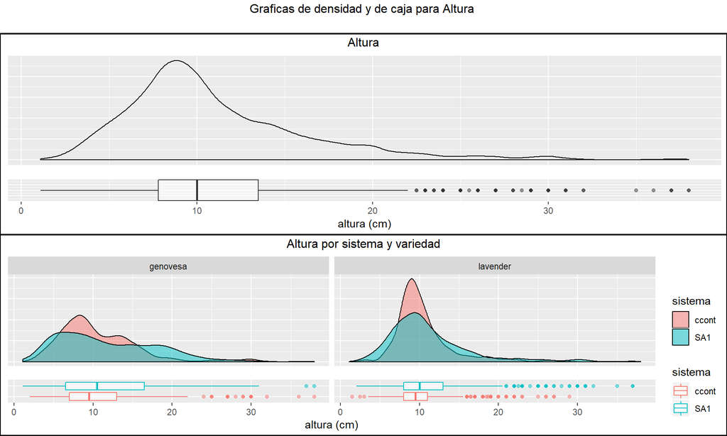

```r
#Graficas altura
p1<-ggplot(albahaca, aes(altura)) +
  geom_density(alpha = .5, bw ="bcv")+
  ylab("Densidad")+
  theme(axis.title.x=element_blank(),
        axis.text.x=element_blank(),
        axis.ticks.x=element_blank(),
        axis.title.y=element_blank(),
        axis.text.y=element_blank(),
        axis.ticks.y=element_blank())

p2<-ggplot(albahaca, aes(y=altura)) +
  geom_boxplot(alpha = .5)+
  theme(axis.title.y=element_blank(),
        axis.text.y=element_blank(),
        axis.ticks.y=element_blank())+
  coord_flip()+
  ylab("altura (cm)")

g1 <- grobTree(arrangeGrob(p1, p2,ncol=1, top = "Altura", layout_matrix = matrix(c(1,1,2),ncol = 1)),rectGrob(gp=gpar(lwd=2, fill=NA)))

#Graficas altura-sistema-variedad
p3 <- ggplot(albahaca, aes(altura, fill = sistema)) +
  geom_density(alpha = .5,  bw ="bcv") +
  ylab("Densidad")+
  facet_grid(.~variedad)+
  theme(axis.title.x=element_blank(),
        axis.text.x=element_blank(),
        axis.ticks.x=element_blank(),
        axis.title.y=element_blank(),
        axis.text.y=element_blank(),
        axis.ticks.y=element_blank())

p4<-ggplot(albahaca, aes(x=sistema,y=altura,color=sistema)) +
  geom_boxplot(alpha = .5)+
  theme(axis.title.y=element_blank(),
        axis.text.y=element_blank(),
        axis.ticks.y=element_blank(),
        strip.background = element_blank(),
        strip.text.x = element_blank())+
  facet_grid(.~variedad)+
  coord_flip()+
  ylab("altura (cm)")

g2 <- grobTree(arrangeGrob(p3, p4,ncol=1, top = "Altura por sistema y variedad", layout_matrix = matrix(c(1,1,2),ncol = 1)),rectGrob(gp=gpar(lwd=2, fill=NA)))

#Unión de graficas
grid.arrange(g1, g2, ncol=1, top = "Graficas de densidad y de caja para Altura \n")
```

Se ve que los datos de altura cuentan con varios valores extremos y asimetría positiva, puede ser que se necesite una transformación de datos para la creación de modelos sobre estos datos.

Respecto a la relación entre variedad y sistema, se ve que existen pequeñas diferencias en las medianas de los sistema acuapónico y cama contenida, por otro lado, se nota que los datos del sistema contenido son más variables que los de la cama contenida, esta variabilidad se nota mucho más en la variedad genovesa respecto a la variedad lavender.

Adicional al sistema y variedad, la atura tiene una relación con la variable independiente DDS, que representa los días que han pasado desde la siembra, para hacer el análisis visual graficaremos la relación altura por DDS, y agregaremos una línea de tendencia para ver el comportamiento en el tiempo, así mismo veremos la relación con sistema y variedad.

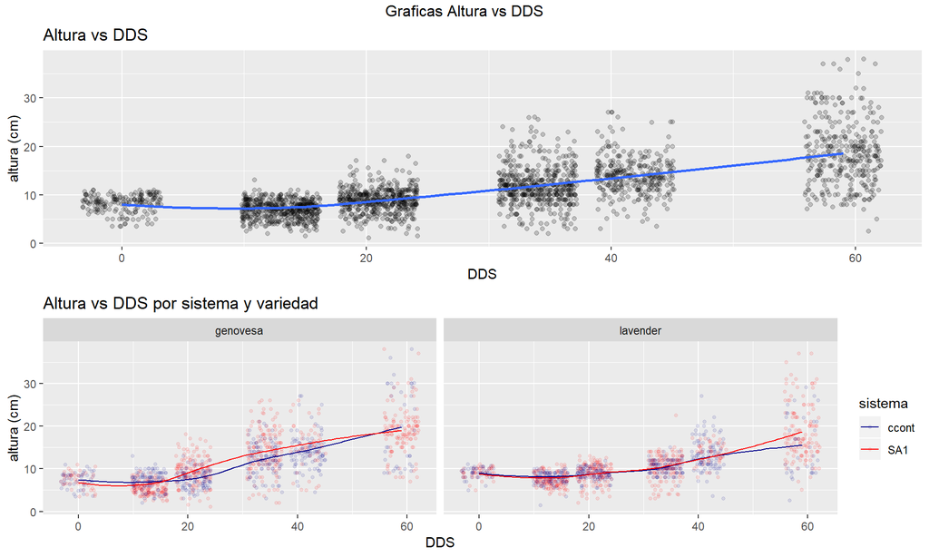

```r
#Graficos Altura en el tiempo
p5<-ggplot(albahaca, aes(DDS,altura)) +
  geom_jitter(alpha=0.2)+
  geom_smooth(method = "loess", se = F) +
  ggtitle("Altura vs DDS")+
  ylab("altura (cm)")

p6 <- ggplot(albahaca, aes(DDS,altura, color = sistema)) +
  geom_jitter(alpha=0.1,size=1)+
  geom_smooth(method = "loess", se = F,size=0.5) +
  ggtitle("Altura vs DDS por sistema y variedad") +
  scale_color_manual(values = c("darkblue","red"))+
  facet_grid(.~variedad)+
  ylab("altura (cm)")

grid.arrange(p5,p6, ncol=1, top="Graficas Altura vs DDS")
```

Vemos que en el tiempo la altura se mantiene estable más o menos hasta el día 15 y luego crece a un ritmo más o menos constante, sin embargo, también se nota que a medida que pasa el tiempo la altura se vuelve cada vez más variable. Respecto a los sistemas y variedades, no se notan grandes diferencias tanto entre variedad como entre sistemas.

## 2.2 Graficas tallos totales.

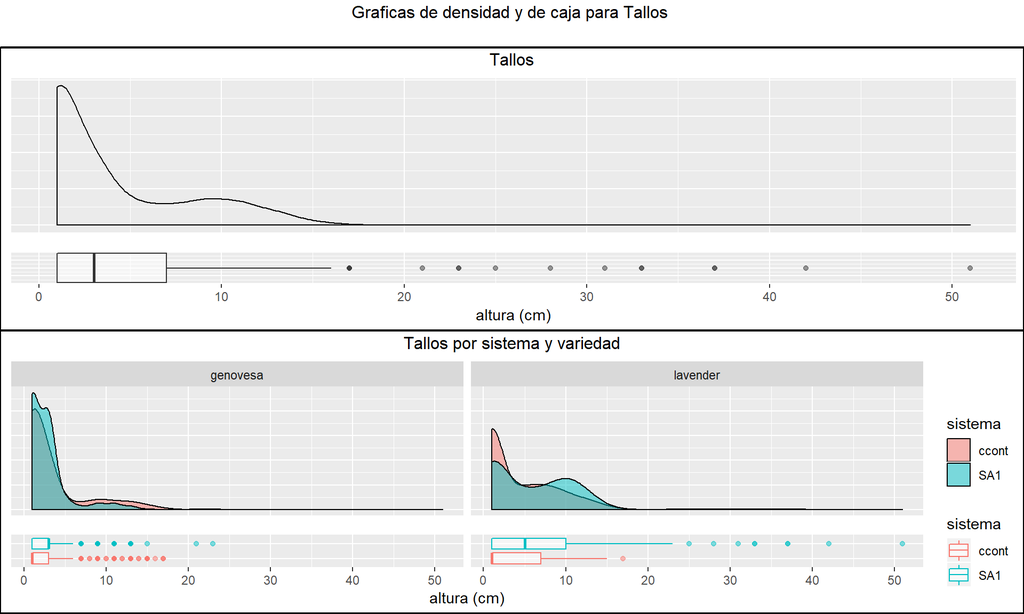

```r
#Graficas tallos
p8<-ggplot(albahaca, aes(tallos_totales)) +
  geom_density(alpha = .5, bw ="bcv")+
  ylab("Densidad")+
  theme(axis.title.x=element_blank(),
        axis.text.x=element_blank(),
        axis.ticks.x=element_blank(),
        axis.title.y=element_blank(),
        axis.text.y=element_blank(),
        axis.ticks.y=element_blank())

p9<-ggplot(albahaca, aes(y=tallos_totales)) +
  geom_boxplot(alpha = .5)+
  theme(axis.title.y=element_blank(),
        axis.text.y=element_blank(),
        axis.ticks.y=element_blank())+
  coord_flip()+
  ylab("altura (cm)")

g3 <- grobTree(arrangeGrob(p8, p9,ncol=1, top = "Tallos", layout_matrix = matrix(c(1,1,2),ncol = 1)),rectGrob(gp=gpar(lwd=2, fill=NA)))

#Graficas tallos-sistema-variedad
p10 <- ggplot(albahaca, aes(tallos_totales, fill = sistema)) +
  geom_density(alpha = .5 , bw ="bcv") +
  ylab("Densidad")+
  facet_grid(.~variedad)+
  theme(axis.title.x=element_blank(),
        axis.text.x=element_blank(),
        axis.ticks.x=element_blank(),
        axis.title.y=element_blank(),
        axis.text.y=element_blank(),
        axis.ticks.y=element_blank())

p11<-ggplot(albahaca, aes(x=sistema,y=tallos_totales,color=sistema)) +
  geom_boxplot(alpha = .5)+
  theme(axis.title.y=element_blank(),
        axis.text.y=element_blank(),
        axis.ticks.y=element_blank(),
        strip.background = element_blank(),
        strip.text.x = element_blank())+
  facet_grid(.~variedad)+
  coord_flip()+
  ylab("altura (cm)")

g4 <- grobTree(arrangeGrob(p10, p11,ncol=1, top = "Tallos por sistema y variedad", layout_matrix = matrix(c(1,1,2),ncol = 1)),rectGrob(gp=gpar(lwd=2, fill=NA)))

#Unión de graficas
grid.arrange(g3, g4, ncol=1, top = "Graficas de densidad y de caja para Tallos \n")
```

Los datos de los tallos se asemejan a una distribución de poisson, como es de esperarse para datos de conteo, sin embargo, se nota que los datos estarían muy dispersos (varianza mayor a la media que difiere con el supuesto de igualdad de una distribución poisson). Esto nos indica que debemos evaluar modelos de regresión con distribución binomial negativa en adición a los modelos de regresión de poisson.

Por otro lado, vemos que se nota claramente diferencias entre las medianas del número de tallos, tanto en genovesa como en lavender, para las plantas de cama contenida y sistema acuapónico, donde se nota mayor número de tallos en este último. También se nota que la cantidad de tallos en lavender es vas variable que los datos de genovesa.

Adicional al sistema y variedad, el número de tallos tiene una relación con la variable independiente DDS, que representa los días que han pasado desde la siembra, para hacer el análisis visual graficaremos la relación altura por DDS, y agregaremos una línea de tendencia para ver el comportamiento en el tiempo, así mismo veremos la relación con sistema y variedad.

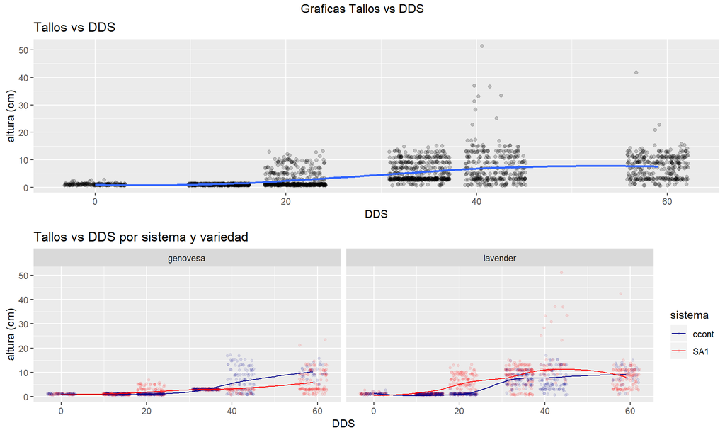

```r
#Graficos tallos en el tiempo
p12<-ggplot(albahaca, aes(DDS,tallos_totales)) +
  geom_jitter(alpha=0.2)+
  geom_smooth(method = "loess", se = F) +
  ggtitle("Tallos vs DDS")+
  ylab("altura (cm)")

p13 <- ggplot(albahaca, aes(DDS,tallos_totales, color = sistema)) +
  geom_jitter(alpha=0.1,size=1)+
  geom_smooth(method = "loess", se = F,size=0.5) +
  ggtitle("Tallos vs DDS por sistema y variedad") +
  scale_color_manual(values = c("darkblue","red"))+
  facet_grid(.~variedad)+
  ylab("altura (cm)")

grid.arrange(p12,p13, ncol=1, top="Graficas Tallos vs DDS")
```

Notamos que hasta el día 15 se mantienen estables los numero de tallos luego suben hasta el día 45 y luego vuelven y se estabilizan, de igual forma notamos que en los últimos días se ven algunos datos extremos.

Respecto a la relación sistema variedad, para genovesa se nota una ventaja del sistema acuapónico hasta aproximadamente el día 32, donde luego toma ventaja es sistema de cama contenida. Para lavender el sistema acuapónico tiene en promedio mayor número de tallos, pero al acercarse al día 59 se igualan para los dos sistemas.

## 2.3 Graficas porcentaje exportación.

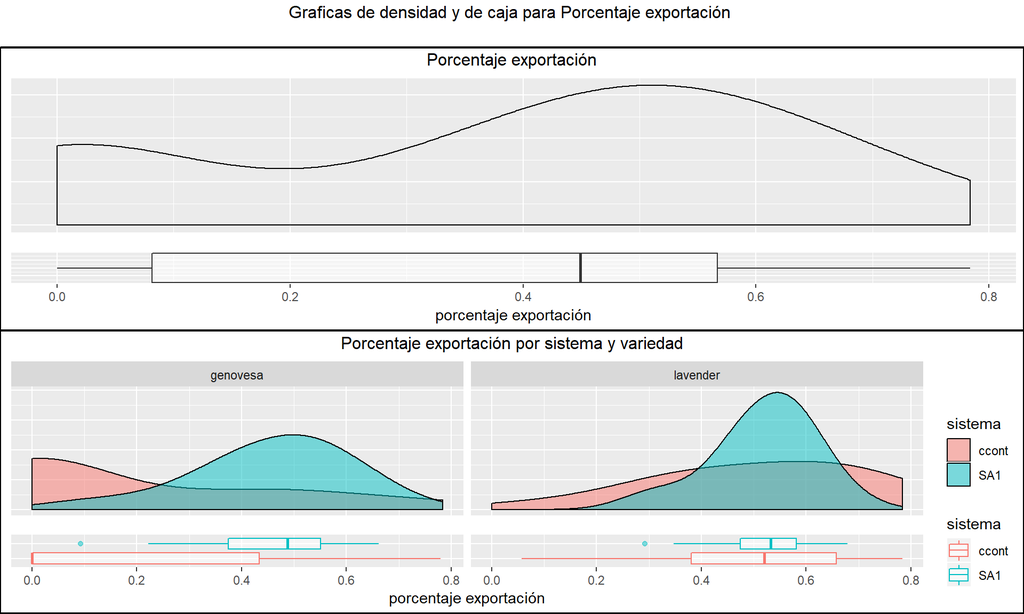

```r
#Graficas porcentaje exportación
p18<-ggplot(cosechalba, aes(per_exportacion)) +
  geom_density(alpha = .5, bw ="bcv")+
  theme(axis.title.x=element_blank(),
        axis.text.x=element_blank(),
        axis.ticks.x=element_blank(),
        axis.title.y=element_blank(),
        axis.text.y=element_blank(),
        axis.ticks.y=element_blank())

p19<-ggplot(cosechalba, aes(y=per_exportacion)) +
  geom_boxplot(alpha = .5)+
  theme(axis.title.y=element_blank(),
        axis.text.y=element_blank(),
        axis.ticks.y=element_blank())+
  coord_flip()+
  ylab("porcentaje exportación")

g7 <- grobTree(arrangeGrob(p18, p19,ncol=1, top = "Porcentaje exportación", layout_matrix = matrix(c(1,1,2),ncol = 1)),rectGrob(gp=gpar(lwd=2, fill=NA)))

#Graficas porcentaje exportación-sistema-variedad
p20 <- ggplot(cosechalba, aes(per_exportacion, fill = sistema)) +
  geom_density(alpha = .5 , bw ="bcv") +
  facet_grid(.~variedad)+
  theme(axis.title.x=element_blank(),
        axis.text.x=element_blank(),
        axis.ticks.x=element_blank(),
        axis.title.y=element_blank(),
        axis.text.y=element_blank(),
        axis.ticks.y=element_blank())

p21<-ggplot(cosechalba, aes(x=sistema,y=per_exportacion,color=sistema)) +
  geom_boxplot(alpha = .5)+
  theme(axis.title.y=element_blank(),
        axis.text.y=element_blank(),
        axis.ticks.y=element_blank(),
        strip.background = element_blank(),
        strip.text.x = element_blank())+
  facet_grid(.~variedad)+
  coord_flip()+
  ylab("porcentaje exportación")

g8 <- grobTree(arrangeGrob(p20, p21,ncol=1, top = "Porcentaje exportación por sistema y variedad", layout_matrix = matrix(c(1,1,2),ncol = 1)),rectGrob(gp=gpar(lwd=2, fill=NA)))

#Unión de graficas
grid.arrange(g7, g8, ncol=1, top = "Graficas de densidad y de caja para Porcentaje exportación \n")
```

Se nota una fuerte bimodalidad en los datos lo cual nos indica que alguna de las combinaciones de variedad y sistema es muy diferente de las demás, debido a esta bimodalidad puede ser necesario que tengamos que transformar los datos para la creación del modelo sobre porcentaje exportación.

Al mirar las interacciones con variedad y sistema se nota como las plantas de variedad genovesa de cama contenida tienden a 0% de porcentaje de exportación y además son en una gran variabilidad para los demás datos, y esto está causando la bimodalidad que se ve en los datos generales. Del lado de las plantas de lavender la mediana no es muy distinta entre los sistemas, pero se nota una gran variabilidad de los datos en cama contenida.

## 2.4 Graficas porcentaje nacional.

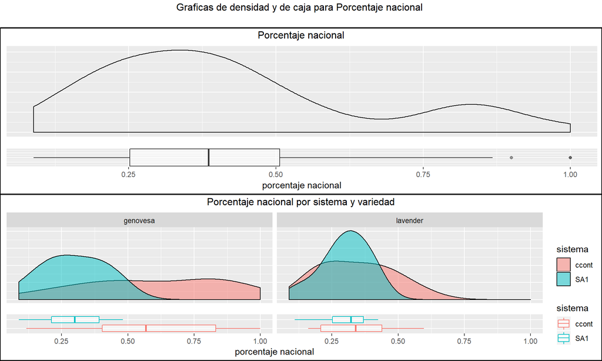

```r
#Graficas porcentaje nacional
p22<-ggplot(cosechalba, aes(per_nacional)) +
  geom_density(alpha = .5, bw ="bcv")+
  theme(axis.title.x=element_blank(),
        axis.text.x=element_blank(),
        axis.ticks.x=element_blank(),
        axis.title.y=element_blank(),
        axis.text.y=element_blank(),
        axis.ticks.y=element_blank())

p23<-ggplot(cosechalba, aes(y=per_nacional)) +
  geom_boxplot(alpha = .5)+
  theme(axis.title.y=element_blank(),
        axis.text.y=element_blank(),
        axis.ticks.y=element_blank())+
  coord_flip()+
  ylab("porcentaje nacional")

g9 <- grobTree(arrangeGrob(p22, p23,ncol=1, top = "Porcentaje nacional", layout_matrix = matrix(c(1,1,2),ncol = 1)),rectGrob(gp=gpar(lwd=2, fill=NA)))

#Graficas porcentaje nacional-sistema-variedad
p24 <- ggplot(cosechalba, aes(per_nacional, fill = sistema)) +
  geom_density(alpha = .5 , bw ="bcv") +
  facet_grid(.~variedad)+
  theme(axis.title.x=element_blank(),
        axis.text.x=element_blank(),
        axis.ticks.x=element_blank(),
        axis.title.y=element_blank(),
        axis.text.y=element_blank(),
        axis.ticks.y=element_blank())

p25<-ggplot(cosechalba, aes(x=sistema,y=per_nacional,color=sistema)) +
  geom_boxplot(alpha = .5)+
  theme(axis.title.y=element_blank(),
        axis.text.y=element_blank(),
        axis.ticks.y=element_blank(),
        strip.background = element_blank(),
        strip.text.x = element_blank())+
  facet_grid(.~variedad)+
  coord_flip()+
  ylab("porcentaje nacional")

g10 <- grobTree(arrangeGrob(p24, p25,ncol=1, top = "Porcentaje nacional por sistema y variedad", layout_matrix = matrix(c(1,1,2),ncol = 1)),rectGrob(gp=gpar(lwd=2, fill=NA)))

#Unión de graficas
grid.arrange(g9, g10, ncol=1, top = "Graficas de densidad y de caja para Porcentaje nacional \n")
```

Una vez más notamos una bimodalidad en los datos, por lo cual es posible que tengamos que transformar los datos para la creación de modelo.

Respecta a la interacción variedad - sistema, se notan diferencias en las medias de genovesa para sistema acuapónico y lavender, pero se ve como la variabilidad de cama contenida es muy grande abarcando casi todo el espectro de porcentajes. En lo referente a lavender, hay una pequeña diferencia en las medias, y se sigue notando una mayor variabilidad en cama contenida.

## 2.5 Graficas SPAD.

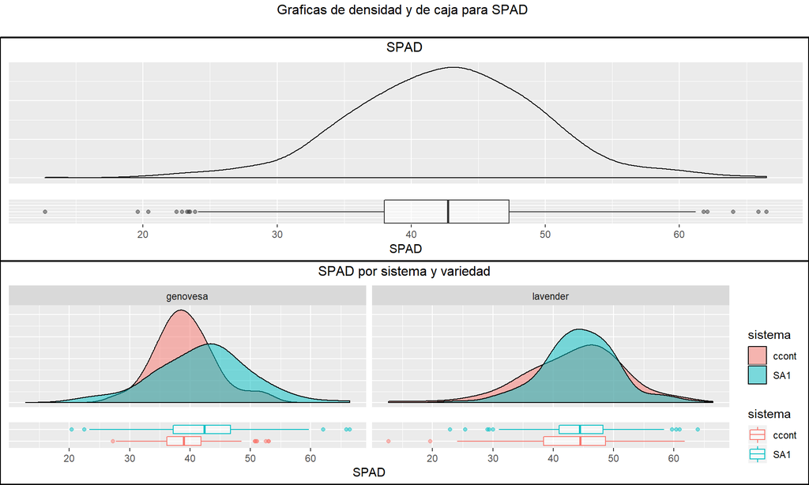

```r
#Graficas SPAD
p26<-ggplot(SPADalba, aes(SPAD)) +
  geom_density(alpha = .5, bw ="bcv")+
  theme(axis.title.x=element_blank(),
        axis.text.x=element_blank(),
        axis.ticks.x=element_blank(),
        axis.title.y=element_blank(),
        axis.text.y=element_blank(),
        axis.ticks.y=element_blank())

p27<-ggplot(SPADalba, aes(y=SPAD)) +
  geom_boxplot(alpha = .5)+
  theme(axis.title.y=element_blank(),
        axis.text.y=element_blank(),
        axis.ticks.y=element_blank())+
  coord_flip()

g11 <- grobTree(arrangeGrob(p26, p27,ncol=1, top = "SPAD", layout_matrix = matrix(c(1,1,2),ncol = 1)),rectGrob(gp=gpar(lwd=2, fill=NA)))

#Graficas SPAD-sistema-variedad
p28 <- ggplot(SPADalba, aes(SPAD, fill = sistema)) +
  geom_density(alpha = .5 , bw ="bcv") +
  facet_grid(.~variedad)+
  theme(axis.title.x=element_blank(),
        axis.text.x=element_blank(),
        axis.ticks.x=element_blank(),
        axis.title.y=element_blank(),
        axis.text.y=element_blank(),
        axis.ticks.y=element_blank())

p29<-ggplot(SPADalba, aes(x=sistema,y=SPAD,color=sistema)) +
  geom_boxplot(alpha = .5)+
  theme(axis.title.y=element_blank(),
        axis.text.y=element_blank(),
        axis.ticks.y=element_blank(),
        strip.background = element_blank(),
        strip.text.x = element_blank())+
  facet_grid(.~variedad)+
  coord_flip()

g12 <- grobTree(arrangeGrob(p28, p29,ncol=1, top = "SPAD por sistema y variedad", layout_matrix = matrix(c(1,1,2),ncol = 1)),rectGrob(gp=gpar(lwd=2, fill=NA)))

#Unión de graficas
grid.arrange(g11, g12, ncol=1, top = "Graficas de densidad y de caja para SPAD \n")
```

Los datos de SPAD se asemejan a una distribución normal. Los datos de genovesa muestran diferencias para las medianas de sistema acuapónico y cama contenida, siendo un poco más variables los de sistema acuapónico. Para lavender no se nota una diferencia grande en las medias de SPAD, y se nota algo más de variabilidad en cama contenida.

## 2.6 Graficas masa seca raíz.

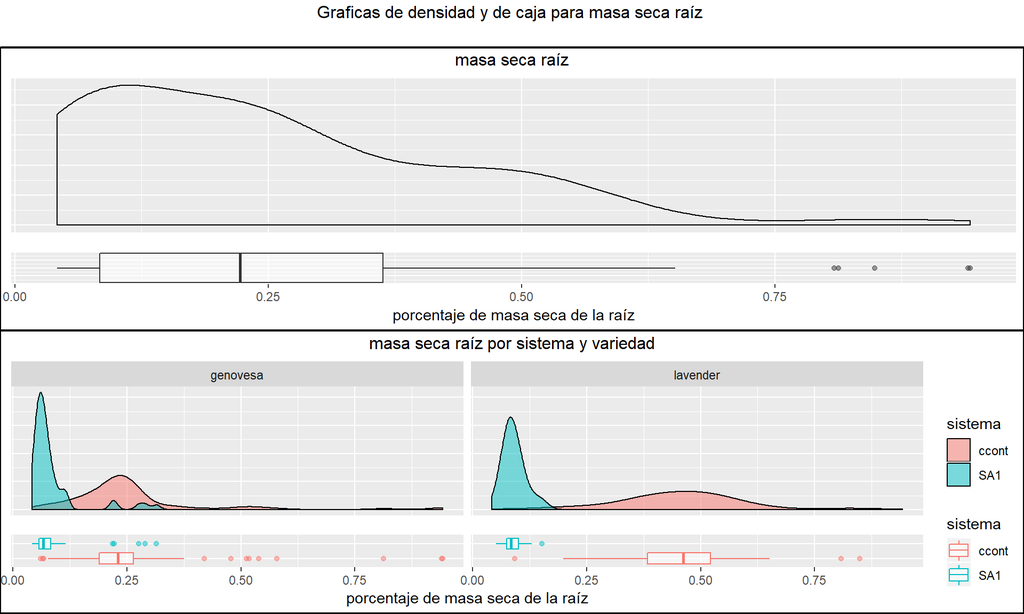

```r
#Graficas masa seca raiz
p30<-ggplot(secofrescoalba, aes(raiz_masa_seca)) +
  geom_density(alpha = .5, bw ="bcv")+
  theme(axis.title.x=element_blank(),
        axis.text.x=element_blank(),
        axis.ticks.x=element_blank(),
        axis.title.y=element_blank(),
        axis.text.y=element_blank(),
        axis.ticks.y=element_blank())

p31<-ggplot(secofrescoalba, aes(y=raiz_masa_seca)) +
  geom_boxplot(alpha = .5)+
  theme(axis.title.y=element_blank(),
        axis.text.y=element_blank(),
        axis.ticks.y=element_blank())+
  coord_flip()+
  ylab("porcentaje de masa seca de la raíz")

g13 <- grobTree(arrangeGrob(p30, p31,ncol=1, top = "masa seca raíz", layout_matrix = matrix(c(1,1,2),ncol = 1)),rectGrob(gp=gpar(lwd=2, fill=NA)))

#Graficas masa seca raiz-sistema-variedad
p32 <- ggplot(secofrescoalba, aes(raiz_masa_seca, fill = sistema)) +
  geom_density(alpha = .5 , bw ="bcv") +
  facet_grid(.~variedad)+
  theme(axis.title.x=element_blank(),
        axis.text.x=element_blank(),
        axis.ticks.x=element_blank(),
        axis.title.y=element_blank(),
        axis.text.y=element_blank(),
        axis.ticks.y=element_blank())

p33<-ggplot(secofrescoalba, aes(x=sistema,y=raiz_masa_seca,color=sistema)) +
  geom_boxplot(alpha = .5)+
  theme(axis.title.y=element_blank(),
        axis.text.y=element_blank(),
        axis.ticks.y=element_blank(),
        strip.background = element_blank(),
        strip.text.x = element_blank())+
  facet_grid(.~variedad)+
  coord_flip()+
  ylab("porcentaje de masa seca de la raíz")

g14 <- grobTree(arrangeGrob(p32, p33,ncol=1, top = "masa seca raíz por sistema y variedad", layout_matrix = matrix(c(1,1,2),ncol = 1)),rectGrob(gp=gpar(lwd=2, fill=NA)))

#Unión de graficas
grid.arrange(g13, g14, ncol=1, top = "Graficas de densidad y de caja para masa seca raíz \n")
```

La distribución de los datos de la masa seca de la raíz tiene una forma muy atípica, y es probable que toque aplicar una transformación para generar un modelo sobre estos. Al mirar las relaciones, entendemos que el comportamiento para estos datos difiere en gran forma entre el sistema acuapónico y cama contenida, donde los porcentajes de sistema acuapónico son muy bajos, en comparación con los de cama contenida. Notamos que la diferencia entre sistema para genovesa es mucho menor que la de lavender.

## 2.7 Graficas peso fresco.

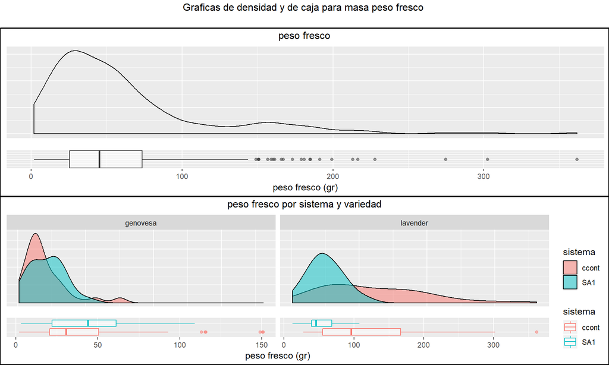

```r
#Graficas peso fresco
p34<-ggplot(secofrescoalba, aes(peso_fresco)) +
  geom_density(alpha = .5, bw ="bcv")+
  theme(axis.title.x=element_blank(),
        axis.text.x=element_blank(),
        axis.ticks.x=element_blank(),
        axis.title.y=element_blank(),
        axis.text.y=element_blank(),
        axis.ticks.y=element_blank())

p35<-ggplot(secofrescoalba, aes(y=peso_fresco)) +
  geom_boxplot(alpha = .5)+
  theme(axis.title.y=element_blank(),
        axis.text.y=element_blank(),
        axis.ticks.y=element_blank())+
  coord_flip()+
  ylab("peso fresco (gr)")

g15 <- grobTree(arrangeGrob(p34, p35,ncol=1, top = "peso fresco", layout_matrix = matrix(c(1,1,2),ncol = 1)),rectGrob(gp=gpar(lwd=2, fill=NA)))

#Graficas masa seca raiz-sistema-variedad
p36 <- ggplot(secofrescoalba, aes(peso_fresco, fill = sistema)) +
  geom_density(alpha = .5 , bw ="bcv") +
  facet_grid(.~variedad)+
  theme(axis.title.x=element_blank(),
        axis.text.x=element_blank(),
        axis.ticks.x=element_blank(),
        axis.title.y=element_blank(),
        axis.text.y=element_blank(),
        axis.ticks.y=element_blank())

p37<-ggplot(secofrescoalba, aes(x=sistema,y=peso_fresco,color=sistema)) +
  geom_boxplot(alpha = .5)+
  theme(axis.title.y=element_blank(),
        axis.text.y=element_blank(),
        axis.ticks.y=element_blank(),
        strip.background = element_blank(),
        strip.text.x = element_blank())+
  facet_grid(.~variedad,scales = "free")+
  coord_flip()+
  ylab("peso fresco (gr)")

g16 <- grobTree(arrangeGrob(p36, p37,ncol=1, top = "peso fresco por sistema y variedad", layout_matrix = matrix(c(1,1,2),ncol = 1)),rectGrob(gp=gpar(lwd=2, fill=NA)))

#Unión de graficas
grid.arrange(g15, g16, ncol=1, top = "Graficas de densidad y de caja para masa peso fresco \n")
```

La distribución de los datos de peso fresto presentan una muy fuerte asimetria positiva, debido a que hay un número considerable de varlores atipicos.

Al mirar las relaciones vemos que la mayoria de datos atipicos se encuentran en la varidead genovesa que proviene de cama contenida. Respecto a las medianas, en genovesa el peso fresco de sistema acuaponico tiene una mediana de peso fresco ligeramente mayor a la de cama contenida, en lavender la media del peso fresco es mayor en cama contenida que en sistema acuapinico.

# 3 Creación de modelos.

El proceso para la creación de modelos para nuestras variables dependientes continuas tiene el siguiente proceso, donde compararemos varios modelos de regresión lineal.

Primero transformamos los datos para que se acomoden a una distribución normal, esta transformación se realizar utilizando la función bestNomralize del paquete de R del mismo nombre, lo que hace esta función es aplicar varias transformaciones a los datos y nos retorna aquella donde los datos transformados se acercan lo más posible a uno distribución normal utilizando la prueba estadística P de Pearson para normalidad.

Una vez con los datos transformados creamos un modelo para los datos transformados y para los datos sin transformar, y comparamos sus residuales y escogemos aquel modelo cuyos residuales se acerquen más a una distribución normal.

Luego al modelo escogido añadiremos un efecto aleatorio en el intercepto y crearemos un modelo mixto el cual compararemos con el modelo original (sin efecto aleatorio), para determinar cuál de los dos modelos escoger, nos basaremos en el Criterio de información de Akaike AIC (por sus siglas en ingles), también en el Criterio de información bayesiano BIC (por sus siglas en ingles) y en la verosimilitud logLik(abreviatura de log Likehood que es su traducción en inglés) de cada modelo, a menor AIC y BIC se considera mejor el modelo y a mayor logLik se considera mejor el modelo.

Después crearemos un modelo mixto con efecto aleatorio en el intercepto y en la pendiente, y lo comparamos con el modelo escogido en el paso anterior, escogiendo aquel con los mejores puntajes AIC, BIC y logLik.

Aplicaremos análisis de varianza al modelo seleccionado del punto anterior para determinar cuáles son las variables que afectan significativamente (p-value menor a 0.05) nuestra variable dependiente y crearemos un modelo basado en el escogido solo usado las variables independientes significativas, luego compararemos estos 2 modelos mediante otra anova, si los modelos no son significativamente distintos, nos quedaremos con el más sencillo, en caso de que sean significativamente distintos nos quedaremos con aquel con las variables completas.

El proceso para las variables dependientes que son datos de conteo (tallos_totales), es similar al descrito para las variables continuas, pero no realizaremos transformación de datos, y en su lugar compararemos dos modelos con los datos originales, el primero será un modelo generalizado para distribución de poisson y el segundo un modelo generalizado para distribución binomial negativa (las dos distribuciones más comunes para datos de conteo). Compararemos estos utilizando una función de dispersión sobre los residuales, aquel con el valor de dispersión más cercano a 1 será el escogido y para los siguientes pasos se utilizará el mismo proceso que los descritos para las variables continuas, pero usando el modelo generalizado con la distribución escogida.

Debido aquel los pasos descritos son múltiples y en cierto grado repetitivos, solo incluiremos en este documento el resultado desde modelo preliminar antes de mirar las significancias para cada variable independiente, hasta el modelo final escogido para cada variable dependiente, mostrando las significancias de cada una de las variables independientes, y los coeficientes de las variables del modelo final. Sin embargo, incluiremos los modelos no escogidos en la sección de códigos de cada variable en caso de que se desee analizarlos y/o reproducir nuestro proceso de selección.

## 3.1 Modelo altura.

Nuestro modelo preliminar para altura es una regresión lineal mixta con efecto aleatorio en el intercepto y en la pendiente, sus p-values para las variables independientes e interacciones entre estas son los siguientes:

```r
#Transformación datos
#altura_t<- bestNormalize(albahaca$altura,loo =T, allow_lambert_s = F, allow_lambert_h = F, allow_orderNorm=F,standardize = F)

#Miarando la transformación selecionada
#altura_t$chosen_transform

#Buscando la mejor transformación
#altura_n<-predict(altura_t)

#Modelos preliminares
#mA1<- lm(altura~DDS*sistema*variedad, albahaca) #Modelo lineal

#mA2<- lm(altura_n~DDS*sistema*variedad, albahaca) #Modelo lineal datos transformados

#plot(density(resid(mA1))); qqnorm(resid(mA1));qqline(resid(mA1)) #Graficas mA1

#plot(density(resid(mA2))); qqnorm(resid(mA2));qqline(resid(mA2)) #Graficas mA2

#mA3<- lmer(altura~DDS*sistema*variedad+(1|id_bloque),albahaca,REML=F,control=lmerControl(optimizer="optimx",calc.derivs=FALSE,optCtrl=list(method="nlminb",starttests = FALSE, kkt = FALSE))) #Modelo lineal mixto con efecto aleatoreo en el intercepto

#anova(mA3,mA1) #Comparación mA3 y mA1

mA4<- lmer(altura~DDS*sistema*variedad+(DDS*sistema*variedad|id_bloque),albahaca,REML=F,control=lmerControl(optimizer="optimx",calc.derivs=FALSE,optCtrl=list(method="nlminb",starttests = FALSE, kkt = FALSE))) #Modelo lineal mixto con efecto aleatoreo en el intercepto y en la pendiente

#anova(mA3,mA4) #Comparación mA3 y mA4

anova(mA4) #Varaibles significativas mA4
```

```
## Type III Analysis of Variance Table with Satterthwaite's method
##                       Sum Sq Mean Sq NumDF  DenDF  F value    Pr(>F)
## DDS                  2778.92 2778.92     1 58.717 295.8731 < 2.2e-16 ***
## sistema                 6.58    6.58     1 38.678   0.7001  0.407902
## variedad              145.26  145.26     1 20.605  15.4654  0.000786 ***
## DDS:sistema            13.42   13.42     1 58.717   1.4288  0.236766
## DDS:variedad          121.16  121.16     1 19.219  12.8995  0.001917 **
## sistema:variedad        2.20    2.20     1 20.605   0.2348  0.633130
## DDS:sistema:variedad   21.76   21.76     1 19.219   2.3172  0.144230
## ---
## Signif. codes:  0 '***' 0.001 '**' 0.01 '*' 0.05 '.' 0.1 ' ' 1
```

Vemos que la variable sistema no es estadísticamente significativa en su efecto sobre la altura de las plantas (p-value 0.41), de igual forma ninguna de las interacción de la variable sistema es significativa (DDS:sistema con un p-value 0.24 y DDS:sistema:variedad con un p-value 0.14), por lo cual hasta aquí llegara el análisis de la variable altura, ya que con los datos que tenemos no se encuentran motivos para rechazar nuestra hipótesis nula, por lo cual podemos decir que no se encuentran diferencias significativas entre las diferencias en la altura de un sistema acuapónico y uno de cama contenida para las variedades lavender y genovesa.

## 3.2 Modelo tallos totales.

Nuestro modelo preliminar para tallos totales es una regresión lineal generalizada con distribución binomial negativa con efecto aleatorio en el intercepto y en la pendiente, sus p-values para las variables independientes e interacciones entre estas son los siguientes:

```r
#Modelos preliminares
#mT1<- glm(tallos_totales~DDS*sistema*variedad, albahaca, family = poisson) #Modelo lineal generalizado poisson

#mT2<- glm.nb(tallos_totales~DDS*sistema*variedad, albahaca) #Modelo lineal generalizado binomial negativo

#dispersion(mT1,"poisson") #Dispersión mT1

#dispersion(mT2,"nb") #Dispersión mT2

#plot(density(resid(mT1))); qqnorm(resid(mT1));qqline(resid(mT1)) #Graficas mT1

#plot(density(resid(mT2))); qqnorm(resid(mT2));qqline(resid(mT2)) #Graficas mT2

#mT3<- glmer.nb(tallos_totales~DDS*sistema*variedad+(1|id_bloque),albahaca,control=glmerControl(optimizer="optimx",calc.derivs=FALSE,optCtrl=list(method="nlminb",starttests=FALSE,kkt=FALSE)),nAGQ=0) #Modelo lineal generalizado binomial negativo con efecto aleatoreo en el intercepto

#anova(mT3,mT2) #Comparación mT3 y mT2

#mT4<- glmer.nb(tallos_totales~DDS*sistema*variedad+(DDS*sistema*variedad|id_bloque),albahaca,control=glmerControl(optimizer="optimx",calc.derivs=FALSE,optCtrl=list(method="nlminb",starttests=FALSE,kkt=FALSE)),nAGQ=0) #Modelo lineal generalizado binomial negativo con efecto aleatoreo en el intercepto y en la pendiente

#saveRDS(mT4, "mT4.rds")

mT4<- readRDS("mT4.rds")

#anova(mT3,mT4) #Comparación mT3 y mT4

Anova(mT4) #Variables significativas mT4
```

```
## Analysis of Deviance Table (Type II Wald chisquare tests)
##
## Response: tallos_totales
##                         Chisq Df Pr(>Chisq)
## DDS                  656.2635  1  < 2.2e-16 ***
## sistema                4.9129  1   0.026656 *
## variedad              35.2229  1  2.940e-09 ***
## DDS:sistema            6.3287  1   0.011880 *
## DDS:variedad           0.2117  1   0.645475
## sistema:variedad      21.3757  1  3.775e-06 ***
## DDS:sistema:variedad   6.6825  1   0.009736 **
## ---
## Signif. codes:  0 '***' 0.001 '**' 0.01 '*' 0.05 '.' 0.1 ' ' 1
```

```r
#mT5 <- glmer.nb(tallos_totales~DDS*sistema*variedad-DDS:variedad+(DDS*sistema*variedad-DDS:variedad|id_bloque),albahaca,control=glmerControl(optimizer="optimx",calc.derivs=FALSE,optCtrl=list(method="nlminb",starttests=FALSE,kkt=FALSE)),nAGQ=0)#Modelo basado en mT4 solo las variables signigicativas de mT4.

#saveRDS(mT5, "mT5.rds")

mT5<- readRDS("mT5.rds")

#anova(mT5,mT4) #Comparación mT5 y mT4
```

$$\ln(\hat{y}) = b_0+b_1X_1+b_2X_2+b_3X_3+b_4X_1X_2+b_5X_2X_3+b_iX_1X_2X_3+Z_iu_i+\varepsilon$$
Adicionalmente:
$$b_i = \begin{cases}
\begin{split}
b_6&, \:si\: X_2=ccont\\
b_7&, \:si\: X_2=SA1\\
\end{split}
\end{cases}$$

Donde $\ln(\hat{y})$ es el logaritmo natural del número de tallos predichos, $b_0$ es nuestro intercepto, $b_1$, $b_2$,$b_3$, $b_4$, $b_5$, $b_6$, $b_7$ son los coeficientes de regresión, $X_1$ es DDS, $X_2$ es el sistema donde ccont tendrá un valor de 0 y SA1 tendrá un valor de 1, $X_3$ es la variedad donde genovesa tendrá un valor de 0 y lavender tendrá un valor de 1, $Z_i$ es id_bloque y $u_i$ es el efecto aleatorio añadido por el bloque (tanto el intercepto como en la pendiente) y por último $\varepsilon$ es el error al azar.

Este es el resumen para nuestro modelo mixto final para tallos_totales:

```r
#Resumen modelo final tallos totales
summary(mT5)
```

```
## Generalized linear mixed model fit by maximum likelihood (Adaptive
##   Gauss-Hermite Quadrature, nAGQ = 0) [glmerMod]
##  Family: Negative Binomial(12.0213)  ( log )
## Formula:
## tallos_totales ~ DDS * sistema * variedad - DDS:variedad + (DDS *
##     sistema * variedad - DDS:variedad | id_bloque)
##    Data: albahaca
## Control:
## glmerControl(optimizer = "optimx", calc.derivs = FALSE, optCtrl = list(method = "nlminb",
##     starttests = FALSE, kkt = FALSE))
##
##      AIC      BIC   logLik deviance df.resid
##   9303.1   9562.0  -4606.5   9213.1     2287
##
## Scaled residuals:
##     Min      1Q  Median      3Q     Max
## -2.1572 -0.5184 -0.0834  0.3341  7.7651
##
## Random effects:
##  Groups    Name                              Variance  Std.Dev. Corr
##  id_bloque (Intercept)                       0.7540274 0.86835
##            DDS                               0.0001235 0.01111  -1.00
##            sistemaSA1                        0.5216101 0.72223  -0.88
##            variedadlavender                  2.5965203 1.61137  -1.00
##            DDS:sistemaSA1                    0.0001404 0.01185   0.32
##            sistemaSA1:variedadlavender       1.1429767 1.06910   0.96
##            DDS:sistemaccont:variedadlavender 0.0017807 0.04220   1.00
##            DDS:sistemaSA1:variedadlavender   0.0001672 0.01293   0.47
##
##
##
##   0.88
##   1.00  0.89
##  -0.32 -0.73 -0.35
##  -0.96 -0.84 -0.97  0.31
##  -1.00 -0.89 -1.00  0.34  0.97
##  -0.47 -0.80 -0.48  0.90  0.35  0.48
## Number of obs: 2332, groups:  id_bloque, 74
##
## Fixed effects:
```

[output cut: 16 more lines]

```
## DDS:sistemaccont:variedadlavender *
## DDS:sistemaSA1:variedadlavender
## ---
## Signif. codes:  0 '***' 0.001 '**' 0.01 '*' 0.05 '.' 0.1 ' ' 1
##
## Correlation of Fixed Effects:
##             (Intr) DDS    sstSA1 vrddlv DDS:sSA1 ssSA1: DDS:s:
## DDS         -0.920
## sistemaSA1  -0.870  0.801
## variddlvndr -0.929  0.813  0.809
## DDS:sstmSA1  0.672 -0.730 -0.905 -0.594
## sstmSA1:vrd  0.813 -0.712 -0.830 -0.875  0.682
## DDS:sstmcc:  0.896 -0.809 -0.779 -0.983  0.591    0.861
## DDS:sstSA1:  0.000  0.000  0.104  0.000 -0.141   -0.385  0.000
## convergence code: 1
```

Los coeficientes para los efectos fijos de nuestro modelo final para tallos totales, con sus correspondientes intervalos de confianza con un nivel del 95% son los siguientes:

```r
#Coeficientes mT5 con intercalos de confianza
(cbind(summary(mT5)[[10]][,1:2],confint(mT5, method = "Wald")[37:44,])) %>% round(4) %>% as.data.frame()
```

|  | Estimate | Std. Error | 2.5 % | 97.5 % |
| --- | --- | --- | --- | --- |
| (Intercept) | 0.2012 | 0.1714 | -0.1347 | 0.5370 |
| DDS | 0.0346 | 0.0030 | 0.0287 | 0.0404 |
| sistemaSA1 | -0.4092 | 0.1970 | -0.7953 | -0.0231 |
| variedadlavender | -0.5560 | 0.2973 | -1.1386 | 0.0266 |
| DDS:sistemaSA1 | -0.0022 | 0.0041 | -0.0102 | 0.0058 |
| sistemaSA1:variedadlavender | 1.3503 | 0.3397 | 0.6845 | 2.0161 |
| DDS:sistemaccont:variedadlavender | 0.0195 | 0.0079 | 0.0041 | 0.0349 |
| DDS:sistemaSA1:variedadlavender | -0.0036 | 0.0042 | -0.0119 | 0.0047 |

La siguiente es la representación gráfica de nuestro modelo final para tallos totales, con un intervalo de confianza del 95% basado en 100 simulaciones de los efectos fijos del mismo:

[figure not shown]

```r
#simulación variables de efecto fijo
albahacaSim<-expand.grid(DDS=seq(0,59,7),variedad=c("genovesa","lavender"), sistema =c("ccont","SA1"))

#Simulación
#albahaca_pred <- function(.) {
#  predict(., newdata=albahacaSim, re.form=~0, , type="response")
#}

#mT5boot <- bootMer(mT5, albahaca_pred, nsim=100, use.u=F, type="parametric",seed = 2314)

#saveRDS(mT5boot,"mT5boot.rds")

mT5boot <-readRDS("mT5boot.rds")

mT5boot.CI <- bootCI(mT5boot)

albahacaSim2 <- cbind(albahacaSim, mT5boot.CI)

#Gráfica simulación
ggplot(albahacaSim2, aes(DDS, fit, fill=sistema, color = sistema))+
  geom_line(size=1)+
  geom_ribbon(aes(x=DDS, ymin=lwr,ymax=upr,fill=sistema, color = sistema), alpha=0.2)+
  facet_grid(.~variedad)+
  ggtitle("Representación gráfica modelo tallos_totales \npara 100 simulaciones con 95% de intervalo de confianza")+
  ylab("altura (cm)")
```

De nuestra simulación podemos ver que, para la variedad genovesa, durante el tiempo, el número de tallos es siempre mayor para en cama contenida que en sistema acuapónico. En el caso de la variedad lavender se ve como la cantidad de tallos es mayor en sistema acuapónico, pero aproximadamente hacia el día 40 la tendencia cambia siendo cama contenida la que presenta más tallos.

Podemos ver también que la cantidad de tallos en menos variable en genovesa que en lavender, y para esta última se nota que la variabilidad de cama contenida es muy fuerte.

## 3.3 Modelo porcentaje exportación.

Nuestro modelo preliminar para porcentaje exportación es una regresión lineal simple, sus p-values para las variables independientes e interacciones entre estas son los siguientes:

```r
#Buscando la mejor transformación
#exportacion_t<- bestNormalize(cosechalba$per_exportacion,loo =T, allow_lambert_s = F, allow_lambert_h = F, allow_orderNorm=F, standardize = F)

#Mirando mejor transformación
#exportacion_t$chosen_transform

#Transformación datos
#exportacion_n<-predict(exportacion_t)

#Modelos preliminares
mE1<- lm(per_exportacion~sistema*variedad, cosechalba) #Modelo lineal

#mE2<- lm(exportacion_n~sistema*variedad, cosechalba) #Modelo lineal datos transformados

#plot(density(resid(mE1),bw = "bcv")); qqnorm(resid(mE1));qqline(resid(mE1)) #Graficas mP1

#plot(density(resid(mE2),bw = "bcv")); qqnorm(resid(mE2));qqline(resid(mE2)) #Graficas mP2

#mE3<- lmer(per_exportacion~sistema*variedad+(1|id_bloque),cosechalba,REML=F,control=lmerControl(optimizer="optimx",calc.derivs=FALSE,optCtrl=list(method="nlminb",starttests = FALSE, kkt = FALSE))) #Modelo lineal mixto con efecto aleatoreo en el intercepto

#anova(mE3,mE1) #Comparación mE3 y mE1

anova(mE1) #Varaibles significativas mP1
```

```
## Analysis of Variance Table
##
## Response: per_exportacion
##                  Df Sum Sq Mean Sq F value    Pr(>F)
## sistema           1 0.7568 0.75679 18.0845 5.510e-05 ***
## variedad          1 0.8474 0.84736 20.2487 2.195e-05 ***
## sistema:variedad  1 0.3181 0.31814  7.6025  0.007166 **
## Residuals        83 3.4733 0.04185
## ---
## Signif. codes:  0 '***' 0.001 '**' 0.01 '*' 0.05 '.' 0.1 ' ' 1
```

Con todas las variables independientes con p-values cercanos a 0 nuestro modelo preliminar para porcentaje exportación se convierte en nuestro modelo final para esa variable, el cual tiene la siguiente formula:

$$\hat{y} = b_0+b_1X_1+b_2X_2+b_3X_1X_2+\varepsilon$$

Donde $\hat{y}$ es el porcentaje de exportación predicho, $b_0$ es nuestro intercepto, $b_1$, $b_2$ y $b_3$ son los coeficientes de regresión, $X_1$ es el sistema donde ccont tendrá un valor de 0 y SA1 tendrá un valor de 1, $X_2$ es la variedad donde genovesa tendrá un valor de 0 y lavender tendrá un valor de 1, y por último $\varepsilon$ es el error al azar.

Este es el resumen para nuestro modelo final para per_exportacion:

```r
#Resumen modelo
summary(mE1)
```

```
##
## Call:
## lm(formula = per_exportacion ~ sistema * variedad, data = cosechalba)
##
## Residuals:
##      Min       1Q   Median       3Q      Max
## -0.44996 -0.19182 -0.02177  0.11062  0.58813
##
## Coefficients:
##                             Estimate Std. Error t value Pr(>|t|)
## (Intercept)                  0.19182    0.03508   5.468 4.70e-07 ***
## sistemaSA1                   0.26269    0.05963   4.405 3.13e-05 ***
## variedadlavender             0.31561    0.06077   5.194 1.44e-06 ***
## sistemaSA1:variedadlavender -0.25183    0.09134  -2.757  0.00717 **
## ---
## Signif. codes:  0 '***' 0.001 '**' 0.01 '*' 0.05 '.' 0.1 ' ' 1
##
## Residual standard error: 0.2046 on 83 degrees of freedom
## Multiple R-squared:  0.3563, Adjusted R-squared:  0.333
## F-statistic: 15.31 on 3 and 83 DF,  p-value: 5.146e-08
```

Los coeficientes para las variables independientes de nuestro modelo final para per_exportacion, con sus correspondientes intervalos de confianza a un nivel del 95% son los siguientes:

```r
#Coeficientes mE1 con intercalos de confianza
(cbind(summary(mE1)[[4]][,1:2],confint(mE1))) %>% round(4) %>% as.data.frame()
```

|  | Estimate | Std. Error | 2.5 % | 97.5 % |
| --- | --- | --- | --- | --- |
| (Intercept) | 0.1918 | 0.0351 | 0.1220 | 0.2616 |
| sistemaSA1 | 0.2627 | 0.0596 | 0.1441 | 0.3813 |
| variedadlavender | 0.3156 | 0.0608 | 0.1947 | 0.4365 |
| sistemaSA1:variedadlavender | -0.2518 | 0.0913 | -0.4335 | -0.0702 |

La siguiente es la representación gráfica de nuestro modelo final para porcentaje exportación, con un intervalo de confianza del 95% basado en 1000 simulaciones:

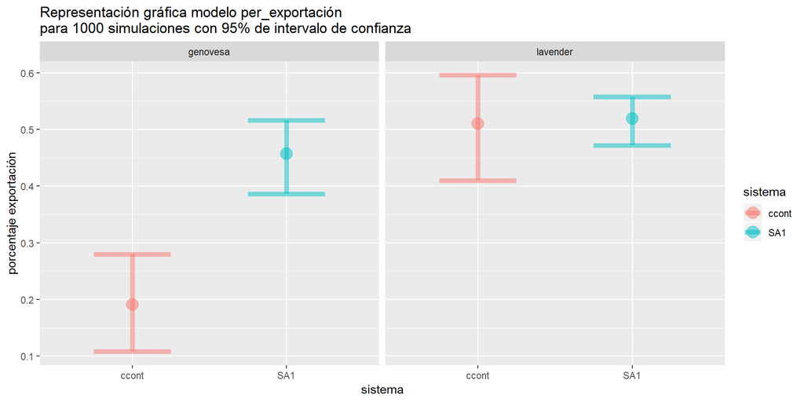

```r
cosechalbaSim<-expand.grid(variedad=c("genovesa","lavender"), sistema =c("ccont", "SA1"))

cosecha_pred <- function(.) {
  predict(., newdata=cosechalbaSim, type="response")
}
#Simulación modelo
set.seed(3214)
mE1boot <- Boot(mE1, cosecha_pred, R=1000)

mE1boot.CI <- bootCI(mE1boot)

cosechalbaSim3 <- cbind(cosechalbaSim,mE1boot.CI)

#Gráfica simulación
ggplot(cosechalbaSim3, aes(sistema, fit, fill=sistema, color = sistema))+
  geom_point(size=5, alpha=0.5)+
  geom_errorbar(aes(ymin = lwr, ymax = upr), width = 0.5, alpha=0.5,size=2)+
  facet_grid(.~variedad)+
  ggtitle("Representación gráfica modelo per_exportación \npara 1000 simulaciones con 95% de intervalo de confianza")+
  ylab("porcentaje exportación")
```

Los puntos medios de porcentaje de exportación para lavender son muy cercanos, aunque cama contenida es más variable. Para genovesa los puntos medios de porcentaje de exportación son más altos en sistema acuapónico.

## 3.4 Modelo porcentaje nacional.

Nuestro modelo preliminar para porcentaje nacional es una regresión lineal mixta con efecto aleatorio en el intercepto, sus p-values para los efectos fijos e interacciones entre estos son los siguientes:

```r
#Buscando la mejor transformación
#nacional_t<- bestNormalize(cosechalba$per_nacional,loo =T, allow_lambert_s = F, allow_lambert_h = F, allow_orderNorm=F, standardize = F)

#Mirando mejor transformación
#nacional_t$chosen_transform

#Transformación datos
#nacional_n<-predict(nacional_t)

#Modelos preliminares
#mN1<- lm(per_nacional~sistema*variedad, cosechalba) #Modelo lineal

#mN2<- lm(nacional_n~sistema*variedad, cosechalba) #Modelo lineal datos transformados

#plot(density(resid(mN1),bw = "bcv")); qqnorm(resid(mN1));qqline(resid(mN1)) #Graficas mN1

#plot(density(resid(mN2),bw = "bcv")); qqnorm(resid(mN2));qqline(resid(mN2)) #Graficas mN2

mN3<- lmer(per_nacional~sistema*variedad+(1|id_bloque),cosechalba,REML=F,control=lmerControl(optimizer="optimx",calc.derivs=FALSE,optCtrl=list(method="nlminb",starttests = FALSE, kkt = FALSE))) #Modelo lineal mixto con efecto aleatoreo en el intercepto

#anova(mN3,mN1) #Comparación mN3 y mN1

anova(mN3) #Varaibles significativas mN3
```

```
## Type III Analysis of Variance Table with Satterthwaite's method
##                   Sum Sq Mean Sq NumDF  DenDF F value    Pr(>F)
## sistema          0.33893 0.33893     1 81.221  19.096 3.645e-05 ***
## variedad         0.18234 0.18234     1 81.221  10.274  0.001930 **
## sistema:variedad 0.19542 0.19542     1 81.221  11.011  0.001357 **
## ---
## Signif. codes:  0 '***' 0.001 '**' 0.01 '*' 0.05 '.' 0.1 ' ' 1
```

Con todos los efectos fijos con p-values cercanos a 0 nuestro modelo preliminar para porcentaje nacional se convierte en nuestro modelo final para esa variable, el cual tiene la siguiente formula:

$$\hat{y} = b_0+b_1X_1+b_2X_2+b_3X_1X_2+Z_iu_i+\varepsilon$$

Donde $\hat{y}$ es el porcentaje nacional predicho, $b_0$ es nuestro intercepto, $b_1$, $b_2$ y $b_3$ son los coeficientes de regresión, $X_1$ es el sistema donde ccont tendrá un valor de 0 y SA1 tendrá un valor de 1, $X_2$ es la variedad donde genovesa tendrá un valor de 0 y lavender tendrá un valor de 1, $Z_i$ es id_bloque y $u_i$ es el efecto aleatorio añadido por el bloque (en el intercepto) y por último $\varepsilon$ es el error al azar.

Este es el resumen para nuestro modelo final para per_nacional:

```r
#Resumen modelo
summary(mN3)
```

```
## Linear mixed model fit by maximum likelihood . t-tests use
##   Satterthwaite's method [lmerModLmerTest]
## Formula: per_nacional ~ sistema * variedad + (1 | id_bloque)
##    Data: cosechalba
## Control:
## lmerControl(optimizer = "optimx", calc.derivs = FALSE, optCtrl = list(method = "nlminb",
##     starttests = FALSE, kkt = FALSE))
##
##      AIC      BIC   logLik deviance df.resid
##    -47.2    -32.4     29.6    -59.2       81
##
## Scaled residuals:
##     Min      1Q  Median      3Q     Max
## -2.2968 -0.4734  0.1023  0.5515  1.7111
##
## Random effects:
##  Groups    Name        Variance Std.Dev.
##  id_bloque (Intercept) 0.01299  0.1140
##  Residual              0.01775  0.1332
## Number of obs: 87, groups:  id_bloque, 71
##
## Fixed effects:
##                             Estimate Std. Error       df t value Pr(>|t|)
## (Intercept)                  0.60521    0.03543 57.92290  17.084  < 2e-16
## sistemaSA1                  -0.30941    0.05443 75.37609  -5.684 2.35e-07
## variedadlavender            -0.26253    0.05535 75.76469  -4.744 9.67e-06
## sistemaSA1:variedadlavender  0.26708    0.08049 81.22085   3.318  0.00136
##
## (Intercept)                 ***
## sistemaSA1                  ***
## variedadlavender            ***
## sistemaSA1:variedadlavender **
## ---
## Signif. codes:  0 '***' 0.001 '**' 0.01 '*' 0.05 '.' 0.1 ' ' 1
##
## Correlation of Fixed Effects:
##             (Intr) sstSA1 vrddlv
## sistemaSA1  -0.651
## variddlvndr -0.640  0.417
## sstmSA1:vrd  0.440 -0.676 -0.688
```

Los coeficientes para efectos fijos de nuestro modelo final para per_nacional, con sus correspondientes intervalos de confianza a un nivel del 95% son los siguientes:

```r
#Coeficientes mN3 con intercalos de confianza
(cbind(summary(mN3)[[10]][,1:2],confint(mN3,method ="Wald")[-(1:2),])) %>% round(4) %>% as.data.frame()
```

|  | Estimate | Std. Error | 2.5 % | 97.5 % |
| --- | --- | --- | --- | --- |
| (Intercept) | 0.6052 | 0.0354 | 0.5358 | 0.6746 |
| sistemaSA1 | -0.3094 | 0.0544 | -0.4161 | -0.2027 |
| variedadlavender | -0.2625 | 0.0553 | -0.3710 | -0.1541 |
| sistemaSA1:variedadlavender | 0.2671 | 0.0805 | 0.1093 | 0.4248 |

La siguiente es la representación gráfica de nuestro modelo final para porcentaje nacional, con un intervalo de confianza del 95% basado en 1000 simulaciones:

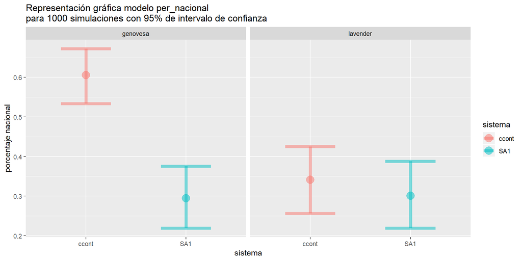

```r
#Simulación
cosecha_pred_mix <- function(.) {
  predict(., newdata=cosechalbaSim, re.form=~0, , type="response")
}

mN3boot <- bootMer(mN3, cosecha_pred_mix, nsim=1000, use.u=F, type="parametric",seed = 2314)

mN3boot.CI <- bootCI(mN3boot)

cosechalbaSim4 <- cbind(cosechalbaSim,mN3boot.CI)

#Gráfica simulación
ggplot(cosechalbaSim4, aes(sistema, fit, fill=sistema, color = sistema))+
  geom_point(size=5, alpha=0.5)+
  geom_errorbar(aes(ymin = lwr, ymax = upr), width = 0.5, alpha=0.5,size=2)+
  facet_grid(.~variedad)+
  ggtitle("Representación gráfica modelo per_nacional \npara 1000 simulaciones con 95% de intervalo de confianza")+
  ylab("porcentaje nacional")
```

Vemos como en genovesa el porcentaje nacional medio es mayor en cama contenida que en sistema acuapónico, en lavender, las medias son muy similares con siendo ligeramente mayor el porcentaje nacional medio en cama contenida.

## 3.5 Modelo SPAD.

```r
#Buscando la mejor transformación
SPAD_t<- bestNormalize(SPADalba$SPAD ,loo =T, allow_lambert_s = F, allow_lambert_h = F, allow_orderNorm=F, standardize = F,quiet = T)

#Mirando mejor transformación
#SPAD_t$chosen_transform

#Transformación datos
SPAD_n<-predict(SPAD_t)

#Modelos preliminares
#mS1<- lm(SPAD~sistema*variedad, SPADalba) #Modelo lineal

#mS2<- lm(SPAD_n~sistema*variedad, SPADalba) #Modelo lineal datos transformados

#plot(density(resid(mS1),bw = "bcv")); qqnorm(resid(mS1));qqline(resid(mS1)) #Graficas mS1

#plot(density(resid(mS2),bw = "bcv")); qqnorm(resid(mS2));qqline(resid(mS2)) #Graficas mS2

mS3<- lmer(SPAD_n~sistema*variedad+(1|id_bloque),SPADalba,REML=F,control=lmerControl(optimizer="optimx",calc.derivs=FALSE,optCtrl=list(method="nlminb",starttests = FALSE, kkt = FALSE))) #Modelo lineal mixto con efecto aleatoreo en el intercepto

#anova(mS3,mS2) #Comparación mS3 y mS1

anova(mS3) #Varaibles significativas mS3
```

```
## Type III Analysis of Variance Table with Satterthwaite's method
##                   Sum Sq Mean Sq NumDF  DenDF F value   Pr(>F)
## sistema          1050.52 1050.52     1  59.21  5.9193 0.018015 *
## variedad         1368.14 1368.14     1 330.15  7.7090 0.005808 **
## sistema:variedad  465.36  465.36     1 330.15  2.6221 0.106337
## ---
## Signif. codes:  0 '***' 0.001 '**' 0.01 '*' 0.05 '.' 0.1 ' ' 1
```

```r
mS4<- lmer(SPAD_n~sistema+variedad+(1|id_bloque),SPADalba,REML=F,control=lmerControl(optimizer="optimx",calc.derivs=FALSE,optCtrl=list(method="nlminb",starttests = FALSE, kkt = FALSE))) #Modelo lineal mixto con efecto aleatoreo en el intercepto sin interacción sistema:variedad

#anova(mS3,mS4) #Comparación mS3 y mS4
```

Vemos que, con excepción de la interacción sistema:variedad, todas las demás variables independientes son significativas (p_values<0.05) en su efecto sobre el SPAD, con lo cual nuestro modelo final para SPAD quedaría expresado en la siguiente formula:

$$\frac{\hat{y}^{\lambda}-1}{\lambda} = b_0+b_1X_1+b_2X_2+Z_iu_i+\varepsilon$$

Donde $(\hat{y}^{\lambda}-1)/\lambda$ es el SPAD predicho transformado aplicando una transformación de Box-Cox con un $\lambda=1.196054$, $b_0$ es nuestro intercepto, $b_1$ y $b_2$ son los coeficientes de regresión, $X_1$ es el sistema donde ccont tendrá un valor de 0 y SA1 tendrá un valor de 1, $X_2$ es la variedad donde genovesa tendrá un valor de 0 y lavender tendrá un valor de 1, $Z_i$ es id_bloque, $u_i$ es el efecto aleatorio añadido por el bloque (en el intercepto) y por último $\varepsilon$ es el error al azar.

Este es el resumen para nuestro modelo final para SPAD:

```r
#Resumen modelo
summary(mS4)
```

```
## Linear mixed model fit by maximum likelihood . t-tests use
##   Satterthwaite's method [lmerModLmerTest]
## Formula: SPAD_n ~ sistema + variedad + (1 | id_bloque)
##    Data: SPADalba
## Control:
## lmerControl(optimizer = "optimx", calc.derivs = FALSE, optCtrl = list(method = "nlminb",
##     starttests = FALSE, kkt = FALSE))
##
##      AIC      BIC   logLik deviance df.resid
##   6176.3   6199.5  -3083.1   6166.3      755
##
## Scaled residuals:
##     Min      1Q  Median      3Q     Max
## -4.1217 -0.5416  0.0242  0.5888  3.3188
##
## Random effects:
##  Groups    Name        Variance Std.Dev.
##  id_bloque (Intercept)  30.51    5.524
##  Residual              177.50   13.323
## Number of obs: 760, groups:  id_bloque, 72
##
## Fixed effects:
##                  Estimate Std. Error      df t value Pr(>|t|)
## (Intercept)        69.678      1.365  90.326  51.047   <2e-16 ***
## sistemaSA1          3.925      1.641  58.344   2.392   0.0200 *
## variedadlavender    3.064      1.264 332.256   2.425   0.0159 *
## ---
## Signif. codes:  0 '***' 0.001 '**' 0.01 '*' 0.05 '.' 0.1 ' ' 1
##
## Correlation of Fixed Effects:
##             (Intr) sstSA1
## sistemaSA1  -0.654
## variddlvndr -0.463  0.000
```

Los coeficientes para los efectos fijos de nuestro modelo final para SPAD, con sus correspondientes intervalos de confianza a un nivel del 95% son los siguientes:

```r
#Coeficientes mS4 con intercalos de confianza
(cbind(summary(mS4)[[10]][,1:2],confint(mS4,method ="Wald")[-(1:2),])) %>% round(4) %>% as.data.frame()
```

|  | Estimate | Std. Error | 2.5 % | 97.5 % |
| --- | --- | --- | --- | --- |
| (Intercept) | 69.6781 | 1.3650 | 67.0027 | 72.3534 |
| sistemaSA1 | 3.9247 | 1.6408 | 0.7087 | 7.1407 |
| variedadlavender | 3.0644 | 1.2638 | 0.5874 | 5.5414 |

La siguiente es la representación gráfica de nuestro modelo final para SPAD, con un intervalo de confianza del 95% basado en 1000 simulaciones:

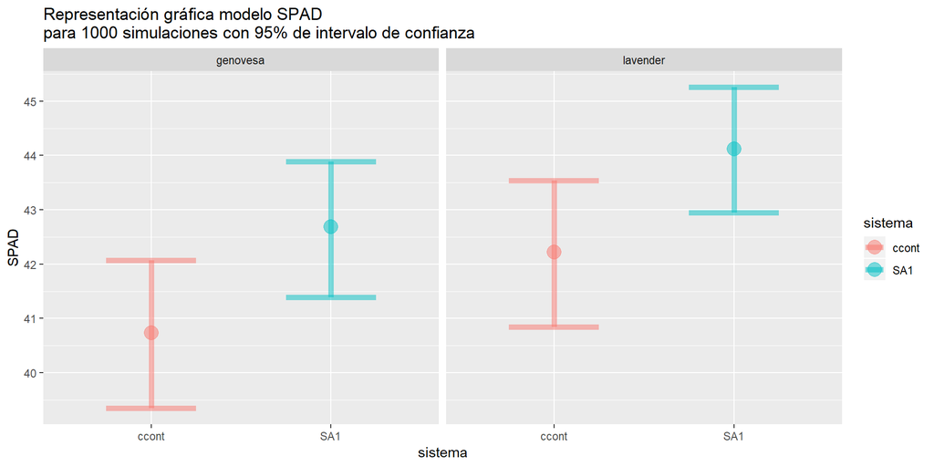

```r
#Simulación modelo
mS4boot <- bootMer(mS4, cosecha_pred_mix, nsim=1000, use.u=F, type="parametric",seed = 2314)

mS4boot.CI <- bootCI(mS4boot) %>% mutate_all(funs(predict(SPAD_t,.,inverse = T)))

SPADSim <- cbind(cosechalbaSim,mS4boot.CI)

#Gráfica simulación
ggplot(SPADSim, aes(sistema, fit, fill=sistema, color = sistema))+
  geom_point(size=5, alpha=0.5)+
  geom_errorbar(aes(ymin = lwr, ymax = upr), width = 0.5, alpha=0.5,size=2)+
  facet_grid(.~variedad)+
  ggtitle("Representación gráfica modelo SPAD \npara 1000 simulaciones con 95% de intervalo de confianza")+
  ylab("SPAD")
```

Vemos tanto para genovesa como para lavender que la media de SPAD es más alta en sistema acuapónico que en cama contenida, así mismo las medias de SPAD de lavender son más altas que las de genovesa.

## 3.6 Modelo masa seca raíz.

Nuestro modelo preliminar para raiz_masa_seca es una regresión lineal mixta con efecto aleatorio en el intercepto, sobre los datos con transformación de logaritmo base 10, sus p-values para los efectos fijos e interacciones entre estos son los siguientes:

```r
#Buscando la mejor transformación
raiz_t<- bestNormalize(secofrescoalba$raiz_masa_seca ,loo =T, allow_lambert_s = F, allow_lambert_h = F, allow_orderNorm=F, standardize = F)
```

```r
#Mirando mejor transformación
#raiz_t$chosen_transform

#Transformación datos
raiz_n<-predict(raiz_t)

#Modelos preliminares
#mR1<- lm(raiz_masa_seca~sistema*variedad, secofrescoalba) #Modelo lineal

#mR2<- lm(raiz_n~sistema*variedad, secofrescoalba) #Modelo lineal datos transformados

#plot(density(resid(mR1),bw = "bcv")); qqnorm(resid(mR1));qqline(resid(mR1)) #Graficas mS1

#plot(density(resid(mR2),bw = "bcv")); qqnorm(resid(mR2));qqline(resid(mR2)) #Graficas mS2

mR3<- lmer(raiz_n~sistema*variedad+(1|id_bloque),secofrescoalba,REML=F,control=lmerControl(optimizer="optimx",calc.derivs=FALSE,optCtrl=list(method="nlminb",starttests = FALSE, kkt = FALSE))) #Modelo lineal mixto con efecto aleatoreo en el intercepto

#anova(mR3,mR2) #Comparación mR3 y mR2

anova(mR3) #Varaibles significativas mR3
```

```
## Type III Analysis of Variance Table with Satterthwaite's method
##                  Sum Sq Mean Sq NumDF  DenDF F value    Pr(>F)
## sistema          7.1563  7.1563     1 100.11 279.840 < 2.2e-16 ***
## variedad         0.6415  0.6415     1 100.11  25.084 2.363e-06 ***
## sistema:variedad 0.2586  0.2586     1 100.11  10.111  0.001962 **
## ---
## Signif. codes:  0 '***' 0.001 '**' 0.01 '*' 0.05 '.' 0.1 ' ' 1
```

Con todos los efectos fijos con p-values cercanos a 0 nuestro modelo preliminar para masa seca raíz se convierte en nuestro modelo final para esa variable, el cual tiene la siguiente formula:

$$\log_{10}(\hat{y}) = b_0+b_1X_1+b_2X_2+b_3X_1X_2+Z_iu_i+\varepsilon$$

Donde $\log_{10}(\hat{y})$ es el logaritmo en base 10 de la masa seca raíz predicha, $b_0$ es nuestro intercepto, $b_1$, $b_2$ y $b_3$ son los coeficientes de regresión, $X_1$ es el sistema donde ccont tendrá un valor de 0 y SA1 tendrá un valor de 1, $X_2$ es la variedad donde genovesa tendrá un valor de 0 y lavender tendrá un valor de 1, $Z_i$ es id_bloque, $u_i$ es el efecto aleatorio añadido por el bloque (en el intercepto) y por ultimo $\varepsilon$ es el error al azar.

Este es el resumen para nuestro modelo final para raiz_masa_seca:

```r
#resumen modelo
summary(mR3)
```

```
## Linear mixed model fit by maximum likelihood . t-tests use
##   Satterthwaite's method [lmerModLmerTest]
## Formula: raiz_n ~ sistema * variedad + (1 | id_bloque)
##    Data: secofrescoalba
## Control:
## lmerControl(optimizer = "optimx", calc.derivs = FALSE, optCtrl = list(method = "nlminb",
##     starttests = FALSE, kkt = FALSE))
##
##      AIC      BIC   logLik deviance df.resid
##   -112.5    -92.3     62.2   -124.5      207
##
## Scaled residuals:
##     Min      1Q  Median      3Q     Max
## -3.3685 -0.3650 -0.0330  0.4063  3.1083
##
## Random effects:
##  Groups    Name        Variance Std.Dev.
##  id_bloque (Intercept) 0.009822 0.09911
##  Residual              0.025573 0.15991
## Number of obs: 213, groups:  id_bloque, 72
##
## Fixed effects:
##                              Estimate Std. Error        df t value
## (Intercept)                  -0.65068    0.02933  50.68457 -22.186
## sistemaSA1                   -0.47251    0.04335  61.58825 -10.899
## variedadlavender              0.28556    0.04335  61.58825   6.587
## sistemaSA1:variedadlavender  -0.22178    0.06975 100.11326  -3.180
##                             Pr(>|t|)
## (Intercept)                  < 2e-16 ***
## sistemaSA1                  5.26e-16 ***
## variedadlavender            1.14e-08 ***
## sistemaSA1:variedadlavender  0.00196 **
## ---
## Signif. codes:  0 '***' 0.001 '**' 0.01 '*' 0.05 '.' 0.1 ' ' 1
##
## Correlation of Fixed Effects:
##             (Intr) sstSA1 vrddlv
## sistemaSA1  -0.677
## variddlvndr -0.677  0.458
## sstmSA1:vrd  0.420 -0.622 -0.622
```

Los coeficientes para los efectos fijos de nuestro modelo final para masa seca raíz, con sus correspondientes intervalos de confianza a un nivel del 95% son los siguientes:

```r
#Coeficientes mR3 con intercalos de confianza
(cbind(summary(mR3)[[10]][,1:2],confint(mR3,method ="Wald")[-(1:2),])) %>% round(4) %>% as.data.frame()
```

|  | Estimate | Std. Error | 2.5 % | 97.5 % |
| --- | --- | --- | --- | --- |
| (Intercept) | -0.6507 | 0.0293 | -0.7082 | -0.5932 |
| sistemaSA1 | -0.4725 | 0.0434 | -0.5575 | -0.3875 |
| variedadlavender | 0.2856 | 0.0434 | 0.2006 | 0.3705 |
| sistemaSA1:variedadlavender | -0.2218 | 0.0698 | -0.3585 | -0.0851 |

La siguiente es la representación gráfica de nuestro modelo final para masa seca raíz, con un intervalo de confianza del 95% basado en 1000 simulaciones:

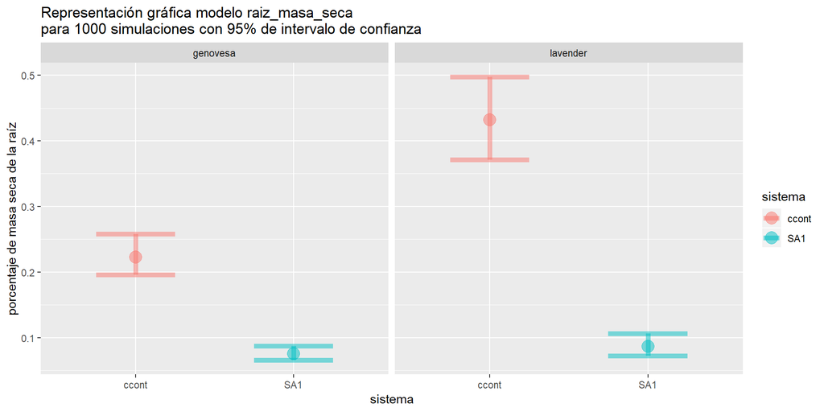

```r
#Simulación modelo
mR3boot <- bootMer(mR3, cosecha_pred_mix, nsim=1000, use.u=F, type="parametric",seed = 2314)

mR3boot.CI <- bootCI(mR3boot) %>% mutate_all(funs(predict(raiz_t,.,inverse = T)))

raizSim <- cbind(cosechalbaSim,mR3boot.CI)

#Gráfica simulación
ggplot(raizSim, aes(sistema, fit, fill=sistema, color = sistema))+
  geom_point(size=5, alpha=0.5)+
  geom_errorbar(aes(ymin = lwr, ymax = upr), width = 0.5, alpha=0.5,size=2)+
  facet_grid(.~variedad)+
  ggtitle("Representación gráfica modelo raiz_masa_seca \npara 1000 simulaciones con 95% de intervalo de confianza")+
  ylab("porcentaje de masa seca de la raíz")
```

Tanto para genovesa como para lavender, la media de la masa seca de la raíz en cama contenida es notablemente mayor a la de sistema acuapónico.

## 3.7 Modelo peso fresco.

```r
#Buscando la mejor transformación
fresco_t<- bestNormalize(secofrescoalba$peso_fresco , standardize = F)
```

```r
#Mirando el valor lambda
#fresco_t$chosen_transform

#Transformación datos
fresco_n<-predict(fresco_t)

#Modelos preliminares
#mF1<- lm(peso_fresco~sistema*variedad, secofrescoalba) #Modelo lineal

#mF2<- lm(fresco_n~sistema*variedad, secofrescoalba) #Modelo lineal datos transformados

#plot(density(resid(mF1),bw = "bcv")); qqnorm(resid(mF1));qqline(resid(mF1)) #Graficas mF1

#plot(density(resid(mF2),bw = "bcv")); qqnorm(resid(mF2));qqline(resid(mF2)) #Graficas mF2

mF3<- lmer(fresco_n~sistema*variedad+(1|id_bloque),secofrescoalba,REML=F,control=lmerControl(optimizer="optimx",calc.derivs=FALSE,optCtrl=list(method="nlminb",starttests = FALSE, kkt = FALSE))) #Modelo lineal mixto con efecto aleatoreo en el intercepto

#anova(mF3,mF2) #Comparación mF3 y mF2

anova(mF3) #Varaibles significativas mR3
```

```
## Type III Analysis of Variance Table with Satterthwaite's method
##                   Sum Sq Mean Sq NumDF  DenDF F value    Pr(>F)
## sistema           4.6105  4.6105     1 84.198  5.3183 0.0235606 *
## variedad         25.0789 25.0789     1 84.198 28.9290 6.617e-07 ***
## sistema:variedad 12.4208 12.4208     1 84.198 14.3277 0.0002869 ***
## ---
## Signif. codes:  0 '***' 0.001 '**' 0.01 '*' 0.05 '.' 0.1 ' ' 1
```

Con todos los efectos fijos con p-values menores a 0.04 nuestro modelo preliminar para peso fresco se convierte en nuestro modelo final para esa variable, el cual tiene la siguiente formula:

$$\frac{(\hat{y}^{\lambda}+1)-1}{\lambda} = b_0+b_1X_1+b_2X_2+b_3X_1X_2+Z_iu_i+\varepsilon$$

Donde $((\hat{y}^{\lambda}+1)-1)/\lambda$ es el peso fresco predicho transformado aplicando una transformación de Yeo-Johnson con un $\lambda=0.1458401$, $b_0$ es nuestro intercepto, $b_1$, $b_2$ y $b_3$ son los coeficientes de regresión, $X_1$ es el sistema donde ccont tendrá un valor de 0 y SA1 tendrá un valor de 1, $X_2$ es la variedad donde genovesa tendrá un valor de 0 y lavender tendrá un valor de 1, $Z_i$ es id_bloque, $u_i$ es el efecto aleatorio añadido por el bloque (en el intercepto) y por ultimo $\varepsilon$ es el error al azar.

Este es el resumen para nuestro modelo final para peso_fresco:

```r
summary(mF3)
```

```
## Linear mixed model fit by maximum likelihood . t-tests use
##   Satterthwaite's method [lmerModLmerTest]
## Formula: fresco_n ~ sistema * variedad + (1 | id_bloque)
##    Data: secofrescoalba
## Control:
## lmerControl(optimizer = "optimx", calc.derivs = FALSE, optCtrl = list(method = "nlminb",
##     starttests = FALSE, kkt = FALSE))
##
##      AIC      BIC   logLik deviance df.resid
##    666.6    686.7   -327.3    654.6      207
##
## Scaled residuals:
##      Min       1Q   Median       3Q      Max
## -2.58753 -0.55005  0.05788  0.46090  2.90489
##
## Random effects:
##  Groups    Name        Variance Std.Dev.
##  id_bloque (Intercept) 0.6645   0.8152
##  Residual              0.8669   0.9311
## Number of obs: 213, groups:  id_bloque, 72
##
## Fixed effects:
##                             Estimate Std. Error      df t value Pr(>|t|)
## (Intercept)                   4.3963     0.2185 53.4821  20.117  < 2e-16
## sistemaSA1                    0.3614     0.3174 60.0758   1.139 0.259388
## variedadlavender              2.2389     0.3174 60.0758   7.054 2.01e-09
## sistemaSA1:variedadlavender  -1.8496     0.4887 84.1980  -3.785 0.000287
##
## (Intercept)                 ***
## sistemaSA1
## variedadlavender            ***
## sistemaSA1:variedadlavender ***
## ---
## Signif. codes:  0 '***' 0.001 '**' 0.01 '*' 0.05 '.' 0.1 ' ' 1
##
## Correlation of Fixed Effects:
##             (Intr) sstSA1 vrddlv
## sistemaSA1  -0.689
## variddlvndr -0.689  0.474
## sstmSA1:vrd  0.447 -0.650 -0.650
```

Los coeficientes para los efectos fijos de nuestro modelo final para peso fresco, con sus correspondientes intervalos de confianza a un nivel del 95% son los siguientes:

```r
#Coeficientes mR3 con intercalos de confianza
(cbind(summary(mF3)[[10]][,1:2],confint(mF3,method ="Wald")[-(1:2),])) %>% round(4) %>% as.data.frame()
```

|  | Estimate | Std. Error | 2.5 % | 97.5 % |
| --- | --- | --- | --- | --- |
| (Intercept) | 4.3963 | 0.2185 | 3.9680 | 4.8247 |
| sistemaSA1 | 0.3614 | 0.3174 | -0.2607 | 0.9834 |
| variedadlavender | 2.2389 | 0.3174 | 1.6169 | 2.8610 |
| sistemaSA1:variedadlavender | -1.8496 | 0.4887 | -2.8074 | -0.8919 |

La siguiente es la representación gráfica de nuestro modelo final para peso fresco, con un intervalo de confianza del 95% basado en 1000 simulaciones:

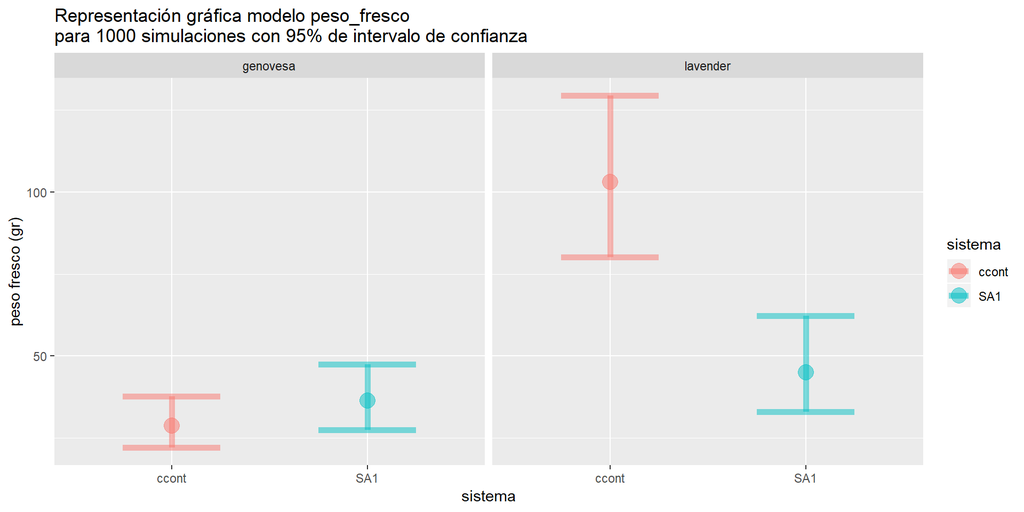

```r
#Simulación modelo
mF3boot <- bootMer(mF3, cosecha_pred_mix, nsim=1000, use.u=F, type="parametric",seed = 2314)

mF3boot.CI <- bootCI(mF3boot) %>% mutate_all(funs(predict(fresco_t,.,inverse = T)))

frescoSim <- cbind(cosechalbaSim,mF3boot.CI)

#Gráfica simulación
ggplot(frescoSim, aes(sistema, fit, fill=sistema, color = sistema))+
  geom_point(size=5, alpha=0.5)+
  geom_errorbar(aes(ymin = lwr, ymax = upr), width = 0.5, alpha=0.5,size=2)+
  facet_grid(.~variedad)+
  ggtitle("Representación gráfica modelo peso_fresco \npara 1000 simulaciones con 95% de intervalo de confianza")+
  ylab("peso fresco (gr)")
```

Vemos que las medias para peso fresco no ligeramente distintas para genovesa, mientras que para lavender se nota que es mucho más grande la media de cama contenida respecto a la de sistema acuapónico.

# 4 Diferencia de las medias

Vimos que las variables tallos_totales, peso_promedio, per_exportacion, per_nacional, SPAD y raiz_masa_seca, presentan una diferencia estadisticamente significativa para sus valores medios entre sistema acuapónico y cama contenida, ahora miraremos la magnitud de esta diferencia.

## 4.1 Diferencia media tallos totales.

Para nuestra simulación para el modelo de tallos totales, solo usaremos lo valores semanales de la variable DDS por lo cual solo simularemos datos para los días 0,7,14,21,28,35,42,49 y 56, esto con el fin de hacer la tabla de resultados de un tamaño adecuado para poder ser analizada.

Diferencia tallos_totales por semana para genovesa:

```r
tallos_tot_diff <- function(.) {
  predict(., newdata=albahacaSim %>% dplyr::filter(sistema=="SA1"), re.form=~0,  type="response") -
  predict(., newdata=albahacaSim %>% dplyr::filter(sistema=="ccont"), re.form=~0 , type="response")
}

#tallos_tot_diff_boot <- bootMer(mT5, tallos_tot_diff, nsim=100, use.u=F, type="parametric",seed = 1234)
#saveRDS(tallos_tot_diff_boot,"tallos_tot_diff_boot.rds")

tallos_tot_diff_boot <- readRDS("tallos_tot_diff_boot.rds")

tallos_tot_diff_boot.CI <- bootCI(tallos_tot_diff_boot)

tallos_tot_diff_genovesa<- cbind(semana=0:8,tallos_tot_diff_boot.CI[1:9,] %>% round(0))
rownames(tallos_tot_diff_genovesa) <- c()
tallos_tot_diff_genovesa
```

| semana | lwr | fit | upr |
| --- | --- | --- | --- |
| 0 | -1 | 0 | 0 |
| 1 | -1 | -1 | 0 |
| 2 | -1 | -1 | 0 |
| 3 | -1 | -1 | -1 |
| 4 | -2 | -1 | -1 |
| 5 | -2 | -2 | -1 |
| 6 | -3 | -2 | -1 |
| 7 | -4 | -3 | -2 |
| 8 | -5 | -3 | -2 |

Diferencia tallos_totales por semana para lavender:

```r
tallos_tot_diff_lavender<- cbind(semana=0:8,tallos_tot_diff_boot.CI[10:18,] %>% round(0))
rownames(tallos_tot_diff_lavender) <- c()
tallos_tot_diff_lavender
```

| semana | lwr | fit | upr |
| --- | --- | --- | --- |
| 0 | 1 | 1 | 2 |
| 1 | 1 | 1 | 2 |
| 2 | 1 | 1 | 2 |
| 3 | 1 | 1 | 2 |
| 4 | 0 | 1 | 2 |
| 5 | -1 | 0 | 1 |
| 6 | -2 | -1 | 1 |
| 7 | -6 | -3 | 1 |
| 8 | -12 | -5 | 0 |

Vemos en lavender que sistema acuapónico presentar de 0 a 2 tallos más que cama contenida hasta la semana 5, luego la tendencia se invierte y en la semana 8 sistema acuapónico presenta entre 0 a 12 tallos menos que cama contenida. con una mediana de menos 5 tallos.

## 4.2 Diferencia media porcentaje exportación.

```r
per_exportacion_diff <- function(.) {
  predict(., newdata=cosechalbaSim %>% dplyr::filter(sistema=="SA1"),  type="response") -
  predict(., newdata=cosechalbaSim %>% dplyr::filter(sistema=="ccont"), type="response")
}
set.seed(3214)
per_exportacion_diff_boot <- Boot(mE1, per_exportacion_diff, R=1000)

per_exportacion_diff_boot.CI <- bootCI(per_exportacion_diff_boot)

cbind(variedad=c("genovesa","lavender"),per_exportacion_diff_boot.CI %>% round(4))
```

|  | variedad | lwr | fit | upr |
| --- | --- | --- | --- | --- |
| 1 | genovesa | 0.1441 | 0.2669 | 0.3689 |
| 2 | lavender | -0.0828 | 0.0080 | 0.1150 |

Se espera que para genovesa el porcentaje del peso destinado a exportación para sistema acuapónico sea de 14.41% a 36.89% mayor que el destinado a exportación en cama contenida, con una mediana de más 26.69%

Se espera que para lavender el porcentaje del peso destinado a exportación para sistema acuapónico sea de 8.28% menor a 11.50% mayor que el destinado a exportación en cama contenida. con una mediana de más 0.8%

## 4.3 Diferencia media porcentaje nacional.

```r
per_nacional_diff <- function(.) {
  predict(., newdata=cosechalbaSim %>% dplyr::filter(sistema=="SA1"), re.form=~0,  type="response") -
  predict(., newdata=cosechalbaSim %>% dplyr::filter(sistema=="ccont"), re.form=~0 , type="response")
}

per_nacional_diff_boot <- bootMer(mN3, per_nacional_diff, nsim=1000, use.u=F, type="parametric",seed = 1234)

per_nacional_diff_boot.CI <- bootCI(per_nacional_diff_boot)

cbind(variedad=c("genovesa","lavender"),per_nacional_diff_boot.CI %>% round(4))
```

|  | variedad | lwr | fit | upr |
| --- | --- | --- | --- | --- |
| 1 | genovesa | -0.4151 | -0.3119 | -0.2032 |
| 2 | lavender | -0.1665 | -0.0425 | 0.0715 |

## 4.4 Diferencia media SPAD.

Debido a que en nuestro modelo para SPAD no existe una interacción entre sistema y variedad, la diferencia en el SPAD será la misma para las dos variedades.

```r
SPAD_diff <- function(.) {
  predict(SPAD_t,
    predict(., newdata=cosechalbaSim %>% dplyr::filter(sistema=="SA1"), re.form=~0,  type="response"),
    inverse = T)-
  predict(SPAD_t,
    predict(., newdata=cosechalbaSim %>% dplyr::filter(sistema=="ccont"), re.form=~0 , type="response"),
    inverse = T)
}

SPAD_diff_boot <- bootMer(mS4, SPAD_diff, nsim=1000, use.u=F, type="parametric",seed = 1234)
dim(SPAD_diff_boot$t)<-c(2000,1)
SPAD_diff_boot.CI <- bootCI(SPAD_diff_boot)

SPAD_diff_boot.CI%>% round(4)
```

| lwr | fit | upr |
| --- | --- | --- |
| 0.5151 | 1.9284 | 3.4367 |

Se espera que para genovesa y lavender el valor de SPAD para sistema acuapónico sea de 0.5151 a 3.4367 puntos mayor que el valor de SPAD para cama contenida, con una mediana de más 1.9284.

## 4.5 Diferencia media masa seca raíz.

```r
raiz_diff <- function(.) {
  predict(raiz_t,
    predict(., newdata=cosechalbaSim %>% dplyr::filter(sistema=="SA1"), re.form=~0,  type="response"),
    inverse = T)-
  predict(raiz_t,
    predict(., newdata=cosechalbaSim %>% dplyr::filter(sistema=="ccont"), re.form=~0 , type="response"),
    inverse = T)
}

raiz_diff_boot <- bootMer(mR3, raiz_diff, nsim=1000, use.u=F, type="parametric",seed = 1234)

raiz_diff_boot.CI <- bootCI(raiz_diff_boot)

cbind(variedad=c("genovesa","lavender"),raiz_diff_boot.CI %>% round(4))
```

| variedad | lwr | fit | upr |
| --- | --- | --- | --- |
| genovesa | -0.1807 | -0.1468 | -0.1189 |
| lavender | -0.4078 | -0.3443 | -0.2824 |

Se espera que para genovesa el porcentaje de masa seca de la raíz para sistema acuapónico sea de 18.07% a 11.89% menor que el de cama contenida, con una mediana de menos 14.68%

## 4.6 Diferencia media peso fresco.

```r
peso_fresco_diff <- function(.) {
  predict(fresco_t,
    predict(., newdata=cosechalbaSim %>% dplyr::filter(sistema=="SA1"), re.form=~0,  type="response"),
    inverse = T)-
  predict(fresco_t,
    predict(., newdata=cosechalbaSim %>% dplyr::filter(sistema=="ccont"), re.form=~0 , type="response"),
    inverse = T)
}

peso_fresco_diff_boot <- bootMer(mF3, peso_fresco_diff, nsim=1000, use.u=F, type="parametric",seed = 1234)

peso_fresco_diff_boot.CI <- bootCI(peso_fresco_diff_boot)

cbind(variedad=c("genovesa","lavender"),peso_fresco_diff_boot.CI %>% round(2))
```

| variedad | lwr | fit | upr |
| --- | --- | --- | --- |
| genovesa | -4.14 | 7.51 | 19.92 |
| lavender | -83.97 | -56.79 | -29.51 |

Se espera que para genovesa el peso fresco de la sección aérea de las plantas para sistema acuapónico sea de 4.14 gramos menos a 19.92 gramos más que en cama contenida, con una mediana de más 7.51 gramos.